[figure not shown]

[Home](https://adamdennett.github.io/school_attainment_tool/) [GitHub](https://github.com/adamdennett/school_attainment_tool)

# How to Pull the Right Lever: School Attainment, Open Data Analytics and Policy in England

Lessons from Brighton and Hove — Version 2.0

Author

Affiliation

Adam Dennett

Bartlett Centre for Advanced Spatial Analysis, University College London

Published

October 15, 2026

# Executive Summary

**Context and motivation**

- The UK Government’s 2026 schools white paper sets ambitious targets including halving the disadvantage attainment gap and improving attendance. Achieving these will require local education authorities to understand the specific drivers of attainment in their areas and choose interventions accordingly.
- This paper argues that the Department for Education’s open data provides most of the raw materials needed, but a crucial gap exists between the availability of data and the availability of accessible, contextualised intelligence for the people making decisions.
- The paper is motivated by the direct experience of the authors in responding to secondary school admissions policy proposals in Brighton and Hove in 2024–25, where policy was designed around a flawed understanding of local attainment drivers.

**National modelling**

- Using multilevel linear mixed effects models fitted to all state-funded secondary schools in England over four years (2021–22 to 2024–25), we show that school-level Attainment 8 is highly predictable — around 80% of the variation is explained by a small number of readily available variables.
- School-level absence is the most powerful predictor of attainment by a considerable margin, with a coefficient roughly 2.6 times larger than that of concentrations of disadvantage. For disadvantaged pupils, nearly half of the variation in school-level performance is explained by attendance alone.
- Prior attainment at Key Stage 2 is the other dominant factor — a large share of the variation in GCSE outcomes reflects accumulated inequalities from before secondary school.
- Concentrations of disadvantage matter, but less than commonly assumed. And for disadvantaged pupils, after controlling for absence and prior attainment, higher concentrations of disadvantaged pupils in a school are associated with slightly *higher*, not lower, attainment. Experiments with different measures of disadvantaged attainment (outcomes) in a model with alternative predictor variables (exploring different measures of disadvantage) confirm the robustness of this observation.
- This is not to recommend that disadvantaged pupils are concentrated in schools with more disadvantaged children — we do not advocate for this. And there may be other, thus far unquantified advantages to mixed cohorts which are beyond the scope of this work. But it is to suggest that deconcentration at all costs might be counter-productive as a strategy to improve disadvantaged student attainment.
- The local authority level Gorard Segregation Index reveals that Brighton and Hove is consistently in the top quarter of LEAs in England for the integration of disadvantaged and non-disadvantages students in its schools, however the Gorard Segregation variable is not statistically significant in the full model. Any harm that segregation causes is already fully mediated by the other variables in the model.
- Many of these relationships are non-linear: the same percentage-point change in a variable yields very different attainment impacts depending on where a school sits on the distribution. This has direct policy consequences that are easily overlooked.

**Brighton and Hove Case Study**

- There are lessons to be learned from the Brighton and Hove case study, all of which are positive for other LEAs. Better analysis of critical policy levers may head off unintended consequences, while an openness to a broader evidence-base and range of voices will lay better policy foundations.
- Brighton and Hove is one of the highest-performing LEAs in England — ranking 14th for disadvantaged attainment, 4th for non-disadvantaged, and 5th overall in our new analysis — once structural factors are accounted for. This was unknown at the time of the 2024 consultation and thus was entirely absent from the public narrative.
- The city’s most acute problem is absence, not social segregation. It had the second worst absence rate in England in 2024–25, yet absence was not part of the policy conversation.
- The City Council’s 2024 admissions proposals were built on the premise that attainment was “driven by economic advantage” and that redistributing disadvantaged pupils across schools would narrow the attainment gap. Our analysis challenges this on several fronts.
- Bringing the city’s worst-affected schools to the national average for absence could yield gains of 3-5 GCSE points. Even dramatic reductions in concentrations of disadvantage would yield gains closer to 1-2 points - but crucially not for disadvantaged students (the intended beneficiaries of the council policy). The policy was pulling a lever with relatively little mechanical advantage in the wrong direction, while ignoring one with considerably more.
- An alternative, contextualised league table for the city reveals that Brighton Aldridge Community Academy (BACA) is the best-performing school in the city for disadvantaged pupils once intake is accounted for, while some other schools, widely perceived as ‘better’ in raw attainment terms, are found to be under-performing relative to their situations.

**The School Attainment Policy Simulator**

- To bridge the gap between open data and actionable intelligence, we have developed an interactive tool built in R Shiny, underpinned by the models in this paper.
- The tool allows users to explore the situation of any school in England, understand which factors most influence attainment in that context, compare schools against contextual expectations, and model the indicative impact of changes to variables such as attendance, pupil composition and workforce stability.
- Development was substantially accelerated by large language model assistance (Anthropic’s Claude) as part of work funded by the UKRI AI4CI hub.

**Recommendations**

- *For the Department for Education:* invest in analytical infrastructure at the local level — fund local authority analytical capacity or develop nationally maintained benchmarking tools that go beyond raw league tables.
- *For local education authorities:* recognise that the factors affecting attainment are multiple, interacting, non-linear and context-dependent. Resist single causal narratives. Create institutional space for genuine deliberation before irreversible decisions are made.
- *For schools, governing bodies and parents:* contextualised benchmarking that accounts for intake and circumstances offers a fairer and more informative basis for understanding school quality than raw Attainment 8 scores or single-word Ofsted ratings.
- *For the Brighton and Hove City Council:* Recognise that the biggest factor affecting disadvantaged attainment in the city is absence from school, not social mixing - the city’s schools are already some of the most socially mixed in England. Commission a study to understand what the different factors are that are leading to the city having the second-worst absence rate in England, understand the full range of impacts that absence has on different groups and develop policies to address these specific challenges while being fully mindful of negative externalities.

**What has changed in Version 2.0, and what it means**

Version 2.0 reworks the analysis in response to peer review of the accompanying journal article, and to criticism the original report attracted. The headline argument is unchanged, and in two respects it is now stronger. But three numbers reported in Version 1 have moved, and one of them moved against us, so it is worth being explicit about the effect on the conclusions.

- **The core finding is unaffected.** Version 1 controlled for prior attainment using only the share of pupils arriving with *low* KS2 scores. Version 2 uses the cohort’s *mean* KS2 score, which captures the whole intake distribution. The absence coefficient moves by under 3% — so the central claim, that attendance is the most consequential lever available to Brighton and Hove, does not depend on the choice at all.
- **The council’s chosen lever looks weaker still.** Properly controlled, the association between concentrations of disadvantage and attainment falls by about a *quarter*. Version 1’s weaker control had left part of the intake difference between high- and low-FSM schools unmeasured, and the disadvantage variable was absorbing it. The case for redistribution as an attainment policy is correspondingly weaker than Version 1 implied.
- **The most contested finding is now clearer, not weaker.** The positive association between disadvantage concentration and *disadvantaged* pupils’ attainment — the result that caused most argument locally — becomes substantially more clearly distinguishable from zero under the better control.
- **One number moved against us.** Brighton and Hove’s rank for disadvantaged attainment, after structural adjustment, falls from 7th of 151 authorities to 14th. The city remains within the strongest tenth, and the substantive point stands, but the earlier figure partly reflected the weaker control and we have corrected it throughout rather than quietly restating it.
- **What absence actually costs the city is now quantified.** The city’s standing depends almost entirely on whether absence is controlled for: 14th with that control, 69th without it. The gap between those two rankings is a measure of what the attendance problem costs the city’s disadvantaged pupils, and it is worth roughly 1.4 Attainment 8 points per pupil. This is new in Version 2.0, and it strengthens the policy conclusion considerably.
- **Absence is not simply a symptom of poverty.** Version 2.0 answers the argument that attendance cannot usefully be tackled directly because poverty will keep regenerating it. Across English local authorities, differences in poverty explain almost none of the difference in absence, and Brighton and Hove has the largest excess absence, relative to its disadvantage profile, of any authority in England.
- **A note of realism about schools.** Version 2.0 sets the findings against sixty years of school-effectiveness research, which consistently puts the share of variation in pupil outcomes attributable to differences *between* schools at roughly 8–15%. Any policy that moves pupils between schools is working on the smaller part of the problem.

**Links**

- The Policy Simulator — https://adam-dennett.shinyapps.io/School_Attainment_Policy_Simulator/
- Underlying Analysis — https://adamdennett.github.io/school_attainment_tool/
- Codebase — https://github.com/adamdennett/school_attainment_tool

**NoteWhat is new in Version 2.0**

This report was first published in May 2025. Version 2.0 incorporates the analysis carried out during peer review of the accompanying journal article, together with responses to criticism the original report attracted. The substantive additions are:

- **A better control for prior attainment.** Version 1 controlled only for the *share of pupils arriving with low* KS2 attainment. Version 2 uses the cohort’s *mean* KS2 score, which captures the whole intake distribution rather than one tail. This is a materially better model, and it changes several of the numbers reported in Version 1 — see Section 5.4.2.
- **The cost of absence, quantified.** Brighton and Hove’s standing for disadvantaged attainment depends almost entirely on whether absence is controlled for. The gap between those two rankings turns out to be a measure of what the city’s attendance problem costs its disadvantaged pupils — see Section 6.2.
- **A response to the “mould and damp” argument**, that absence is merely a symptom of poverty and cannot usefully be tackled on its own (Section 6.7.3).
- **How much schools can matter at all**, set against sixty years of school-effectiveness research (Section 6.7.4).
- **A note on statistical inference** with population rather than sample data (Section 5.3).

Where Version 2 revises a number reported in Version 1, it says so explicitly rather than quietly restating it. Version 1 remains available for reference.

# 1 Introduction

The outcomes of pupils attending schools is a topic of perennial interest to policy makers, and unsurprising given the link to life outcomes (Farquharson et al., 2024) and national economic productivity (Grant, 2017). At the time of writing, the UK Government has just published a schools white paper (DfE, 2026) outlining its ambition to, amongst other things, halve the disadvantage attainment gap, improve attendance, reform admissions and tackle place-based disadvantage, for example in coastal towns.

Farquharson C, McNally S and Tahir I (2024) Education inequalities. *Oxford Open Economics* 3(Supplement_1): i760–i820. DOI: 10.1093/ooec/odad029.

Grant C (2017) *[The Contribution of Education to Economic Growth](https://opendocs.ids.ac.uk/articles/report/The_Contribution_of_Education_to_Economic_Growth/26453986/1)*. The Institute of Development Studies; Partner Organisations.

These are laudable national ambitions and will certainly lead to concerted efforts by local education authorities (LEAs) to try and affect these improvements, but with, inevitably, a list of successes as well as failures. Within England, the situations and circumstances across schools and populations within the different LEAs are as diverse as the range of outcomes experienced. Failure to fully understand the drivers in different local contexts and tailor solutions appropriately will be at the root of any challenges experienced in applying treatments and gaps between observed and expected outcomes.

What will be required are very different sets of local and school-level approaches which are cognisant of the local conditions, in particular the interactions between local socio-economic and demographic profiles and the schools and their characteristics that serve these populations, the geography of the local school landscape and the balance and accessibility of provision available to serve different populations. No two local authorities are the same and as such, no single solution exists to achieve these national ambitions.

This is a very broad backdrop which helps partially situate this report. It emerges from a unique local situation in Brighton and Hove, England — a city not new to experimental schools policies (Allen et al., 2013) and a local case study which helps highlight the very real dangers and unintended outcomes of policy makers attempting to affect broad-brush ‘solutions’ but without a complete understanding of the problems in their local system alongside its unique facets and challenges. Policies which fail to fully understand the specific nature of the local challenges, or pay heed to the negative externalities, will struggle to prescribe an effective treatment and could do more harm than good.

We will argue in this report that while the evidence base is vast and the data plentiful, in Brighton and Hove (and possibly therefore in other LEAs) there can be a crucial disconnect between theory, evidence and local policy making which must be addressed before considering policy changes. While any local education authority might outwardly claim to aspire to evidence-based or evidence-led policy, where good evidence is not easily to hand, where there is not the internal capacity within councils to synthesise theory and data at the pace prescribed by the politicians, or where evidence is selectively filtered to fit a predetermined policy objective, then the risk of making poor decisions is high.

This report offers a different evidence and analytics-based approach to this challenge through presenting both an analysis and an associated tool which should fill many of the localised evidence voids that currently face many LEAs looking to follow through on the national government’s objectives. Our assertion is that the Department for Education already provides most of the raw materials required for making better decisions through its open data publications, but these are under-utilised. If this data can be made easily accessible and digestible for those charged with improving the situation — the schools themselves, their leadership teams and governing boards, the local education authorities or parents asked to contribute to statutory consultations — it will be more feasible to convert good intentions into area-wide beneficial outcomes.

Of course, there will be some LEAs and schools who are already more on top of this than others. Brighton and Hove provides a particularly interesting case study as it objectively out-performs most other LEAs in England but where new policy proposals in 2024 and 2025 reflected a poor grasp of the available evidence. Council Policy decisions have controversially opened the door to unintended negative social, environmental, educational, and health outcomes while our analysis shows the levers pulled are unlikely to lead to the stated educational policy goals being met. Critically, the approach has led to a confused and divided populace where parents might now be making sub-optimal choices for their children while living in a knowledge vacuum. We hope that through illustrating the particular issues in Brighton and Hove and offering potential practical solutions, those in other local education authorities might avoid similar mistakes. We note that the city is also likely to be one of the places targeted by the DfE’s new “Mission Coastal” where issues with disadvantaged communities are relevant, so an enhanced evidence-base will be timely.

The lead author of this report is a resident of Brighton and Hove with lived experience of the effects of the policy development process on local families. This work has emerged from 18 months of discussions with a wider community of parents in the city keen that their children are not negatively impacted by erroneous policy decisions; some of these parents are academics familiar with data and quantitative methods, some are experienced in national policy making, some are involved in schools in the city either through their governing boards or as teaching staff and some are simply parents and residents who want to see good education policy making that will benefit all children in the city. As such, the report builds on a diverse range of perspectives which are relevant to the national government’s ambitions.

This paper will proceed with a review of the recent literature on secondary school attainment in England covering the received wisdom on the drivers of outcomes and identifying relevant gaps and challenges with this work in a policy context and informing our analysis section. We will then give an overview of the background to secondary schools, attainment and other relevant context for our case study city. This will be followed by an outline of the open data available from the Department for Education and a demonstration of the attainment-relevant insights that can be gained through the application of linear mixed effects models. We will then take time to show how new AI tools can be brought to bear to facilitate a more practical understanding of the outputs and how these can all be reconfigured into a dynamic policy tool allowing policy makers and school teams to understand the levels at their disposal and the potential impacts that can be expected. We will conclude with a synthesis and a set of recommendations.

# 2 Literature Review

## 2.1 Benchmarking Secondary School Attainment in England

Research on different aspects of attainment in Secondary Schools in England is plentiful. Most relates to attainment at the end of National Curriculum Key Stage 4 (KS4) measured either in General Certificate of Secondary Education (GSCE - the exam most take at age 16) points, particularly in subjects such as Maths or English, or Attainment 8 — an aggregation of GCSE points across multiple subjects. The exact metrics relating to GSCEs can vary across studies. For example, Morris et al. (2021) measure fine graded point scores, while Houtepen et al. (2020) use both continuous GCSE points based on top 8 qualifications and a binary threshold of 5+ GCSEs at grade C or above including English and Maths. One explanation for this variation — and indeed, complication — is that the way in which GCSEs are graded has evolved over time, as has what people have conceived as the ‘gold standard’. Gillborn et al. (2017) track the evolution from five or more A*-C grades in any subjects (introduced 1988) to the ‘gold standard’ requiring English and mathematics (2005), and subsequently to the English Baccalaureate including sciences, humanities, and languages, and the issues this has caused for defining the ‘attainment gap’. In another piece, Odell (2017) focus on the percentage of students achieving grades C or higher in English, mathematics and at least three other subjects.

<sup>1</sup> Details of English National Curriculum Key Stages https://www.gov.uk/national-curriculum

Leckie G and Goldstein H (2019) The importance of adjusting for pupil background in school value-added models: A study of Progress 8 and school accountability in England. *British Educational Research Journal* 45(3): 518–537. DOI: 10.1002/berj.3511.

Prior L, Jerrim J, Thomson D, et al. (2021) A review and evaluation of secondary school accountability in England: Statistical strengths, weaknesses and challenges for “Progress 8” raised by COVID-19. *Review of Education* 9(3): e3299. DOI: 10.1002/rev3.3299.

Several studies have incorporated prior attainment measures to examine value-added or progress made at secondary school through comparing, for example, exam grades at National Curriculum Key Stage 2 (KS2 - the latter stages of Primary School from ages 7 to 11[^1]) entry, with grades at KS4 exit. Gorard and Siddiqui (2019) compare KS4 outcomes with prior attainment at ages 6, 10, and 13. Gorard et al. (2025) specifically analyse “Progress 8” scores which measure progress between KS2 and KS4 while Stopforth and Gayle (2025) examine the relationship between results at KS2 and subsequent GCSE outcomes. Progress 8 adds a little more nuance to the attainment picture, but it has also been criticised (Leckie and Goldstein, 2019; Prior et al., 2021) mainly because it fails to adjust for pupil background characteristics which are relevant in predicting progress, particularly in places like London. In our analysis, we choose to focus on Attainment 8 and use prior attainment as one of the predictors, rather than incorporate it into the outcome. As we shall see, prior attainment has important interactions with other variables that if ignored, can give a false impression of causality which is important to account for. In addition, Attainment 8 is cited as the measure of choice for assessing the attainment gap in the recent DfE (2026) white paper, so this will be our outcome of choice.

## 2.2 Factors Affecting Attainment

### 2.2.1 Socio-economic Background and Social Class

The determinants of secondary school attainment in England are multifaceted, spanning drivers such as socio-economic background, individual pupil characteristics, school-level factors, and wider contextual influences such as local and national policy. In Brighton and Hove, the narrative and discourse from the Council when proposing changes to the secondary school admissions process in the city zoomed in on the wider socio-economic drivers of pupil attainment, prioritising these above and to the exclusion of all others.

Whether they were right to do this will be discussed later in the paper, however, there has certainly been plentiful research in the UK around socio-economic drivers and outcomes. The Education Policy Institute’s annual report focuses on the disadvantage gap and over successive years shows that, by the time pupils sit their GCSEs, disadvantaged pupils in England are on average around 18 months of learning behind their more affluent peers (Tuckett et al., 2023). This gap narrowed modestly in the decade following 2011, but progress stalled and partially reversed following the COVID-19 pandemic. Importantly, the EPI reports distinguish between persistent and moderate disadvantage, with pupils who have been eligible for Free School Meals (FSM) for most of their school career facing substantially larger gaps than those with intermittent disadvantage.

Tuckett S, Hunt E, Robinson D, et al. (2023) *[EPI Annual Report 2023](https://epi.org.uk/annual-report-2023/)*. London: Education Policy Institute.

Stopforth S, Gayle V and Boeren E (2021) Parental social class and school GCSE outcomes: Two decades of evidence from UK household panel surveys. *Contemporary Social Science* 16(3): 309–324. DOI: 10.1080/21582041.2020.1792967.

Whether or not a student is in receipt of free school meals has been used as a shorthand for disadvantage in both the policy and academic realms for a long time. However, the limitations of FSM as a proxy for disadvantage are well established. Stopforth and Gayle (2025), using linked National Pupil Database and Understanding Society data, demonstrate that finer-grained measures of parental social class — operationalised through the National Statistics Socio-Economic Classification (NS-SEC) — reveal persistent and substantial GCSE attainment gaps that cruder FSM-based analyses tend to understate. Essentially where FSM eligibility doesn’t fully capture disadvantage, equally students might be categorised as “non-disadvantaged” while living in relative poverty and this can affect analysis outcomes. In earlier work, the same authors (Stopforth et al., 2021) were able to show that social class differences in examination outcomes have been enduring across cohorts spanning the 1990s to the 2010s, but it is also the case that the threshold for eligibility is due to change soon in the UK, making comparison between years a future challenge. However, despite these limitations, FSM eligibility is recorded at the pupil and school level and in the absence of other proxies, is widely used, despite its limitations.

One crucial dimension of the social class dimension to secondary school attainment is the fact that inequalities at GCSE level are substantially (though not entirely) mediated by prior attainment at Key Stage 2 — again something we will return to later in this paper. GCSE outcomes reflect accumulated inequalities rather than just those experienced during secondary schooling. Gorard and Siddiqui (2019) reinforce this point using large-scale National Pupil Database (NPD) analyses, showing that the duration of disadvantage — the number of school years a pupil has been FSM-eligible — is a stronger predictor of attainment than disadvantage at any single point in time, and that school-level segregation interacts with this trajectory to exacerbate or moderate outcomes. Again, something we will return to later in this piece.

One final aspect of socio-economic background or social class that is relevant for later on in this paper relates to the idea of concentrations of disadvantage or how mixed or otherwise school pupil cohorts are. This has been a prominent idea in the work of Gorard and also appears in Gorard and Siddiqui (2019) where they propose the idea that pupils do worse in schools with clusters of disadvantage and thus should be as mixed as possible, leading to “improved outcomes of between 0.05 and 0.15 of a standard deviation for almost no cost” (Gorard and Siddiqui, 2019, p.12) — around 1 GCSE grade of improvement in one GCSE subject for a pupil. This communicates an easy, marginal win. However, the idea of “almost no cost” is a conjecture that mistakenly presents a frictionless transition to policy makers. The ‘cost’ to the local council, children and their families will be dependent on what real world consequences there are for a community to implement the change – for example, if children are forced to attend schools that are miles away from their home communities when closer schools could be available.

It is also worth mentioning that while Gorard and Siddiqui (2019)’s pupil-level analysis suggests a negative impact of disadvantaged clustering, it runs counter to a 2015 Department for Education report on the drivers of disadvantaged attainment (Macleod et al., 2015) which reports that higher concentrations of disadvantage in schools are associated with increased success for disadvantaged pupils at KS4.

### 2.2.2 Individual Factors

While contextual factors such as socio-economic background are clearly important, another strand in the literature explores the role of individual-level factors such as the psychological or cognitive characteristics of students or their actions such as attendance, as predictors of attainment. O’Connell and Marks (2022), using Millennium Cohort Study data on 8,303 pupils in England, Wales and Northern Ireland, find that cognitive ability (based on ten cognitive ability tests) and conscientiousness together account for substantially more variance in GCSE scores than measures of socio-economic background. While this finding sits within a contested debate — with evidence that psychological characteristics are themselves shaped by social conditions (Rakesh et al., 2025) — it underlines the importance of non-socio-economic factors in explaining at least some of the variation in attainment outcomes. Morris et al. (2021) using the Avon Longitudinal Study of Parents and Children (ALSPAC) cohort data, demonstrate that school enjoyment at age six predicts GCSE results approximately a decade later at a magnitude comparable to social class and gender, and that this association is not fully explained by family background or prior cognitive ability.

Rakesh D, Lee PA, Gaikwad A, et al. (2025) Annual Research Review: Associations of socioeconomic status with cognitive function, language ability, and academic achievement in youth: A systematic review of mechanisms and protective factors. *Journal of Child Psychology and Psychiatry* 66(4): 417–439. DOI: 10.1111/jcpp.14082.

Morris TT, Dorling D, Davies NM, et al. (2021) Associations between school enjoyment at age 6 and later educational achievement: Evidence from a UK cohort study. *npj Science of Learning* 6(1): 18. DOI: 10.1038/s41539-021-00092-w.

Houtepen LC, Heron J, Suderman MJ, et al. (2020) Associations of adverse childhood experiences with educational attainment and adolescent health and the role of family and socioeconomic factors: A prospective cohort study in the UK. *PLOS Medicine* 17(3): e1003031. DOI: 10.1371/journal.pmed.1003031.

Adverse childhood experiences (ACEs) represent another individual-level pathway to educational disadvantage. Houtepen et al. (2020), in a study, also using ALSPAC data, show that cumulative ACE exposure is associated with lower GCSE attainment and worse adolescent health outcomes, with effects persisting after adjustment for socio-economic characteristics. These findings point to the importance of separating socio-economic factors from experiential disadvantage, particularly where the former is a strong risk factor for the latter, and suggest that school-level data capturing more crude pupil characteristics like FSM eligibility, may mask heterogeneous pathways to low attainment.

Richards and Smith (2016) using cross-sectional data from secondary schools in Cornwall, identify a novel selection of individual demographic and lifestyle correlates of school attendance, English and Maths attainment, and behavioural sanctions. They find that factors such as low sleep hours and infrequent exercise participation were independent predictors of school performance, while mental health — particularly depression — is independently associated with attainment after controlling for other demographic and lifestyle variables.

Richards G and Smith AP (2016) Demographic and Lifestyle Correlates of School Attendance, English and Maths Attainment, and the Occurrence of Behavioural Sanctions in British Secondary School Children. *Journal of Education, Society and Behavioural Science*: 1–15. DOI: 10.9734/BJESBS/2016/26393.

DfE (2022) [The link between absence and attainment at KS2 and KS4, Academic year 2018/19](https://explore-education-statistics.service.gov.uk/find-statistics/the-link-between-absence-and-attainment-at-ks2-and-ks4/2018-19).

DfE (2025a) *[Link between attendance and attainment](https://www.gov.uk/government/publications/link-between-attendance-and-attainment)*. London: Department for Education.

While these factors can affect attendance as well as attainment, school attendance itself is one of the strongest and most practically significant individual-level predictors of attainment. DfE analysis of 2018/19 KS4 data (DfE, 2022) — the most recent pre-pandemic cohort — documents a stark gradient between absence and GCSE performance: pupils who did not achieve grades 9–4 in English and Maths had an average KS4 absence rate of 8.8%, compared with 5.2% among those achieving a grade 4 pass and 3.7% among those achieving a grade 5 or above. Among persistently absent pupils — defined as missing 10% or more of possible sessions — only 35.6% achieved a standard pass in English and Maths, compared with 83.7% of pupils with no recorded absences; for severely absent pupils (missing more than 50% of sessions), the figure fell to just 11.3%. More recent DfE analysis extends this picture: Year 11 pupils with near-perfect attendance (95–100%) were 1.9 times (almost double) as likely to achieve a grade 5 in English and Maths compared with otherwise similar pupils attending 90–95% of the time — implying that as few as ten additional missed days is associated with a substantially reduced probability of achieving a strong pass (DfE, 2025a).

These cross-sectional associations have been reinforced by longitudinal evidence. Dräger et al. (2024), using the 1970 British Cohort Study, find that school absences in late childhood are associated with lower ultimate educational attainment and a higher likelihood of being out of the labour force in mid-adulthood, after adjustment for a comprehensive set of confounders including socio-economic background, prior cognitive ability, and health. Five missed days at age 10 was associated with a 5.2% higher probability of obtaining no qualifications. The authors caution that the direction of causation is difficult to establish cleanly given that absence and attainment share many common antecedents (disadvantage, health, special educational needs etc.), however in work by the Government’s Social Mobility Commission (Riordan et al., 2021), they are quite clear that the correlation between attendance and progress made by pupil premium students (some of the most disadvantaged students in the schools system) “*is most likely to be causal. This is because there is an intuitive underlying causal mechanism: students not in school are less likely to learn the school curriculum.*”

Dräger J, Klein M and Sosu E (2024) The long-term consequences of early school absences for educational attainment and labour market outcomes. *British Educational Research Journal* 50(4): 1636–1654. DOI: 10.1002/berj.3992.

Riordan S, Jopling M and Starr S (2021) *[Against the odds: Achieving greater progress for secondary students facing socio-economic disadvantage](https://www.gov.uk/government/publications/against-the-odds)*. Social Mobility Commission.

DfE (2024) [Working together to improve school attendance](https://www.gov.uk/government/publications/working-together-to-improve-school-attendance). *GOV.UK*.

Post-pandemic trends have heightened the policy relevance of these findings. Persistent absence (≥10% of sessions missed) has risen steeply from around 10.5% of pupils before the pandemic. While there has been some slow decrease, in 2023/24 it was still around 21.9% in secondary schools with the rate for FSM eligible pupils around 32% (DfE, 2025b). The DfE’s statutory guidance *Working Together to Improve School Attendance* (DfE, 2024) frames attendance as a shared responsibility of schools, academy trusts, local authorities, and families, and sets out a tiered system of support and legal intervention. Critically for analysis of GCSE attainment data, this post-pandemic increase in absence means that school-level attainment figures increasingly reflect not just the characteristics of a school’s pupil intake but also attendance patterns that are themselves socially patterned — with schools serving higher proportions of disadvantaged pupils typically experiencing both higher absence rates and lower raw attainment, compounding the challenge of disentangling school-level from pupil-level effects and the interactions between all of these effects. We will return to this theme in the analysis below as it is a crucial critique of the policy case study we observe in Brighton and Hove as well as something of much wider policy importance.

### 2.2.3 Journey to School

If attendance sits at the heart of the attainment story, then anything that systematically erodes attendance deserves attention in its own right. One factor that the wider literature highlights, but which rarely surfaces in English attainment analyses, is the daily journey to school. The journey-to-school literature is not strictly about attainment — its outcomes are typically measured in sleep, health, wellbeing or absence rather than GCSE points — but its findings matter for attainment by virtue of the chain of mediation that runs through attendance. This becomes a particularly relevant strand of the literature in the policy context discussed later in this paper, where admissions reforms premised on social mixing necessarily entail longer or more complex daily commutes for some pupils.

The most direct link between travel and attainment runs through absence. Thomson (2023), using English National Pupil Database data, shows that pupils with longer journeys to school have measurably higher rates of absence, with effects concentrated among already-disadvantaged groups. Similar patterns have been documented internationally: Cordes et al. (2022) use a natural experiment in New York City school-bus disruptions to show that transit problems directly produce absence; Blagg et al. (2018), in a Washington DC study, find that students who travel further from home to school are absent more often and switch schools more frequently; and Otsuka et al. (2025) report comparable commute-absence relationships in a Japanese setting. The mechanism is intuitive — longer or more uncertain journeys leave less margin for the small frictions (illness, transport delay, weather, family logistics) that turn a marginal day into an absent one — but it is also empirically robust across very different national contexts.

Cordes SA, Rick C and Schwartz AE (2022) Do long bus rides drive down academic outcomes? *Educational Evaluation and Policy Analysis* 44(4): 689–716. DOI: 10.3102/01623737221092450.

Blagg K, Rosenboom V and Chingos MM (2018) *[The Extra Mile: Time to School and Student Outcomes in Washington, DC](https://www.urban.org/sites/default/files/publication/99027/time_to_school_and_student_outcomes_in_dc_1.pdf)*. Urban Institute.

Otsuka Y, Tokiya M, Saitoh I, et al. (2025) Factors associated with school absenteeism due to difficulty awakening: A two-year prospective cohort study of Japanese adolescents. *Environmental Health and Preventive Medicine* 30: 89–89. DOI: 10.1265/ehpm.25-00290.

Fredriksen K, Rhodes J, Reddy R, et al. (2004) Sleepless in chicago: Tracking the effects of adolescent sleep loss during the middle school years. *Child Development* 75(1): 84–95. DOI: https://doi.org/10.1111/j.1467-8624.2004.00655.x.

Yeo SC, Jos AM, Erwin C, et al. (2019) Associations of sleep duration on school nights with self-rated health, overweight, and depression symptoms in adolescents: Problems and possible solutions. *Sleep Medicine* 60: 96–108. DOI: 10.1016/j.sleep.2018.10.041.

Pereira EF, Moreno C and Louzada FM (2014) Increased commuting to school time reduces sleep duration in adolescents. *Chronobiology International* 31(1): 87–94. DOI: 10.3109/07420528.2013.826238.

Pradhan RK and Sinha N (2017) Impact of commuting distance and school timing on sleep of school students. *Sleep and Biological Rhythms* 15(2): 153–158. DOI: 10.1007/s41105-017-0091-0.

Voulgaris CT, Smart MJ and Taylor BD (2019) Tired of commuting? Relationships among journeys to school, sleep, and exercise among American teenagers. *Journal of Planning Education and Research* 39(2): 142–154. DOI: 10.1177/0739456X17725148.

Chairassamee N, Chancharoenchai K and Saraithong W (2024) Getting there: How commuting time and distance impact students’ health. *PLoS One* 19(12): e0314687. DOI: 10.1371/journal.pone.0314687.

Guan H, Xue J, Zhang Y, et al. (2025) Examining the relationship between commuting time, academic achievement, and mental health in rural China: A cross-sectional analysis. *BMC Public Health* 25(1): 1616. DOI: 10.1186/s12889-025-22861-7.

Karan M, Rahal D, Almeida DM, et al. (2021) School commute time, chronotype, and altered HPA axis functioning during adolescence. *Psychoneuroendocrinology* 133: 105371. DOI: 10.1016/j.psyneuen.2021.105371.

Nakajima S, Otsuka Y, Itani O, et al. (2024) Association between commuting and mental health among Japanese adolescents. *Psychiatry and Clinical Neurosciences* 78(10): 588–594. DOI: 10.1111/pcn.13714.

Ding P, Li Y, Feng S, et al. (2023) Do long school commutes undermine teenagers’ wellbeing? Evidence from a nation-wide survey in China. *Journal of Transport & Health* 30: 101605. DOI: 10.1016/j.jth.2023.101605.

Beyond absence, a substantial body of work documents the broader costs that long commutes impose on children. Long journeys are repeatedly associated with reduced sleep duration and poorer sleep quality, with knock-on consequences for psychosocial functioning (Fredriksen et al., 2004; Yeo et al., 2019). Active and short commutes, conversely, are linked to better physical health and fitness outcomes (Faulkner et al., 2013; Pereira et al., 2014; Pradhan and Sinha, 2017; Voulgaris et al., 2019) — a literature that also makes the converse point that displacing pupils into longer car or bus journeys removes a meaningful slice of daily physical activity. Mental health and stress consequences have been documented in adolescent and student populations across multiple settings (Chairassamee et al., 2024; Guan et al., 2025; Karan et al., 2021; Nakajima et al., 2024), with broader wellbeing effects (Ding et al., 2023). None of these studies treats GCSE attainment as the outcome, but each describes a pathway — disrupted sleep, poorer physical health, elevated stress, lower wellbeing — that the attendance and individual-factors literatures already identify as upstream of school performance.

There is also a more qualitative dimension to displacing pupils from their local schools that the attainment-focused literature tends to under-weight. Schools function as community anchors: walked-to schools support after-school participation, friendship groups that map onto local catchments, parental engagement that depends on geographic proximity, and the active-travel pathways that support physical and mental health (Faulkner et al., 2013). Where redistribution policies extend daily commutes, they tend to do so unevenly. Shah (2023), in a case study of extended commutes in Chicago, argues that the burden of long school journeys falls disproportionately on pupils already experiencing other forms of marginalisation. Stein et al. (2021), using US transit data, shows that long-distance transit predicts early high school transfer — itself a known risk factor for poor attainment. These are not peripheral concerns: they are part of the cost-benefit calculus that any policy reorganising pupil flows should engage with, and they form a strand of evidence that we will return to when assessing the Brighton and Hove proposals.

Faulkner G, Stone M, Buliung R, et al. (2013) School travel and children’s physical activity: A cross-sectional study examining the influence of distance. *BMC Public Health* 13(1): 1166. DOI: 10.1186/1471-2458-13-1166.

Shah KB (2023) *[Traversing the City: Examining the Impacts of Extended Commute on Student Wellbeing & High School Experience in Chicago](https://knowledge.uchicago.edu/record/7216)*. Master’s thesis. University of Chicago.

Stein ML, Burdick-Will J and Grigg J (2021) A choice too far: Transit difficulty and early high school transfer. *Educational Researcher* 50(3): 137–144. DOI: 10.3102/0013189X20949504.

### 2.2.4 Ethnicity

Ethnic inequalities in attainment are a persistent dimension of educational disadvantage in England. Gillborn et al. (2017), drawing on 25 years of official statistics from the introduction of GCSEs in 1988 through to 2013, document a persistent gap between Black Caribbean pupils and their White British peers that has proved resistant to successive waves of educational policy. Their analysis shows that improvements in measured attainment for Black Caribbean pupils have repeatedly been outpaced by gains among White British pupils.

Gillborn D, Demack S, Rollock N, et al. (2017) Moving the goalposts: Education policy and 25 years of the Black/White achievement gap. *British Educational Research Journal* 43(5): 848–874. DOI: 10.1002/berj.3297.

Gorard S, Siddiqui N, See BH, et al. (2025) Do School Exclusions and Attainment Outcomes Disproportionately Impact Minority Ethnic Pupils? Analysis of Pupil Characteristics, Segregation, and Outcomes in England. *Education Sciences* 15(1): 6. DOI: 10.3390/educsci15010006.

However, a more recent large-scale NPD-based analysis by Gorard et al. (2025) challenges the attribution of ethnic gaps in attainment and exclusions to ethnicity per se. When pupil-level characteristics — including prior attainment, deprivation, and special educational needs — alongside school-level segregation are controlled for, the apparently disproportionate impact on minority ethnic pupils is substantially reduced.

That said, it’s worth highlighting that other than in comparison with Black Caribbean pupils, the relative underperformance of disadvantaged White British pupils, particularly boys, when compared to almost every other ethnic group, is poor and has attracted significant recent policy attention. Strand (2021), analysing the Second Longitudinal Study of Young People in England (LSYPE2) finds that once socio-economic status and sex are controlled for, ethnic minority groups on average outperform their White British peers (with only Black Caribbean and Black African boys the exception) — making disadvantaged White British pupils, and boys in particular, a clearly underperforming group within the attainment distribution.

Strand S (2021) *Ethnic, socio-economic and sex inequalities in educational achievement at age 16, by Professor Steve Strand*. London: Commission on Ethnic; Racial Disparities.

Commons Education Committee H of (2021) [“Forgotten” White working-class pupils let down by decades of neglect, MPs say - Committees - UK Parliament](https://committees.parliament.uk/committee/203/education-committee/news/156024/forgotten-white-workingclass-pupils-let-down-by-decades-of-neglect-mps-say/).

Commission SM (2021) [The Social Mobility Commission (SMC) responds to report on White working class pupils being “let down”](https://www.gov.uk/government/news/smc-responds-to-report-on-white-working-class-pupils-being-let-down). *GOV.UK*.

This is corroborated by national data cited in a House of Commons Education Committee report: in 2019, fewer than 18% of FSM-eligible White British pupils achieved a strong pass in English and Mathematics, compared with 22.5% of all similarly disadvantaged pupils (Commons Education Committee, 2021). The reasons for this remain contested: the Education Committee reject poverty as the only factor and point to issues such as persistent intergenerational disadvantage alongside negative family experiences of education, lack of social capital and general disengagement with the curriculum, and also note place-based factors such as regional economic challenges and underinvestment. On the other hand, the Social Mobility Commission caution that the phenomenon *is* primarily one of place-based deprivation rather than ethnicity *per se*, and that framing it as a White-specific issue risks obscuring how poverty shapes outcomes across all groups (Commission, 2021). In short, the interactions are complex and mutually reinforcing with causal pathways requiring careful disentangling.

### 2.2.5 School Selectivity

Somewhat less controversial in the literature is the impact of school-level selectivity on outcomes at the school-level. The presence of fee-paying independent schools has long been a feature of the UK schools landscape and their beneficial impacts on attainment for those that can afford them widely presumed, if somewhat misunderstood. Anders et al. (2024), using Millennium Cohort Study data, find that the raw GCSE performance advantage of private school pupils over their state-educated peers effectively disappears once socioeconomic background is controlled for. This finding implies that the observed private school “premium” is primarily a reflection of the highly advantaged intake of independent schools rather than any value added by the schools themselves.

Anders J, Green F, Henderson M, et al. (2024) Private school pupils’ performance in GCSEs (and IGCSEs). *Cambridge Journal of Education* 54(6): 795–813. DOI: 10.1080/0305764X.2024.2420611.

Gorard S, See BH and Siddiqui N (2022) *[Making Schools Better for Disadvantaged Students: The International Implications of Evidence on Effective School Funding](https://doi.org/10.4324/9781003287353)*. London: Routledge.

Allen R and West A (2011) Why do faith secondary schools have advantaged intakes? The relative importance of neighbourhood characteristics, social background and religious identification amongst parents. *British Educational Research Journal* 37(4): 691–712. DOI: 10.1080/01411926.2010.489145.

Andrews J and Johnes R (2016) *[Faith Schools, pupil performance, and social selection](https://dera.ioe.ac.uk/id/eprint/27949/1/Pupil_characteristics_and_performance_at_faith_schools.pdf)*. Education Policy Institute.

The continued presence of grammar schools in parts of the country is perhaps the most overt example of selection within the state sector, and its role in reinforcing socio-economic stratification has been documented by Burgess et al. (2018), who show that high-attaining pupils from lower socio-economic backgrounds are significantly less likely to access grammar schools than similarly able peers from more affluent families. But similarly to the research on independent schools, after controlling for selection effects, their impact on outcomes disappears. Gorard and Siddiqui (2019) and Gorard et al. (2022) further demonstrate, using whole-cohort NPD analyses, that selective systems are associated with higher levels of school segregation by poverty, with downstream effects on the attainment gap and later social status, but they also find that results in grammar schools are broadly as expected given their intake advantage rather than attributable to the schools’ educational effectiveness, with selection leading to no overall benefits for attainment. The less overt selection by socio-economic status which occurs within faith schools (Allen and West, 2011; Andrews and Johnes, 2016) also sees religious schools generally achieve higher raw school-level attainment outcomes that, unless controlled for, can give misleading impressions of school effectiveness.

### 2.2.6 School-Level and Geographic Factors

School-level characteristics — including workforce factors like leadership, teaching quality and teacher effectiveness, teacher turnover and workforce stability, funding, culture and ethos, as well geographic location — also contribute to variation in attainment, though these effects are generally smaller than those attributable to pupil characteristics.

Zuccollo et al. (2023) look at the impact of effective headteachers on schools and their performance and show that effective headteachers (those who improve attainment at the schools they lead while also reducing staff turnover and staff absenteeism) and show that a move from an average (median effectiveness) headteacher to one in the top 84th percentile (around 1 standard deviation above average) and above — is worth around 1 GCSE grade in one GCSE — a similar effect size to the Gorard mixing effect mentioned earlier. The mechanisms through which these leadership effects operate in schools in examined by Sammons et al. (2011) who note that “leadership practice that promotes an orderly and favourable behavioural climate, positive learner motivation and a learning culture that predicts positive changes in pupil behaviour and attendance as intermediate outcomes that themselves promote improvement in attainment.”

Zuccollo J, Cardim Dias J, Jimenez E, et al. (2023) *[The influence of headteachers on their schools](https://epi.org.uk/publications-and-research/the-influence-of-headteachers-on-their-schools/)*. Education Policy Institute.

Sammons P, Gu Q, Day C, et al. (2011) Exploring the impact of school leadership on pupil outcomes: Results from a study of academically improved and effective schools in England Pashiardis P and Brauckmann S (eds.). *International Journal of Educational Management* 25(1): 83–101. DOI: 10.1108/09513541111100134.

Burgess S, Rawal S and Taylor ES (2023) Teachers’ use of class time and student achievement. *Economics of Education Review* 94: 102405. DOI: 10.1016/j.econedurev.2023.102405.

Burgess S, Rawal S and Taylor ES (2022) *[Characterising effective teaching](https://www.nuffieldfoundation.org/project/characterising-effective-teaching-2)*. Nuffield Foundation.

Bernhard R, McDermott T, Hasenhüttl C, et al. (2024) A focus on quality of teaching in schools increases students’ progress of attainment. Evidence from English secondary schools. *School Effectiveness and School Improvement* 35(4): 506–530. DOI: 10.1080/09243453.2024.2398601.

Slater H, Davies NM and Burgess S (2012) Do Teachers Matter? Measuring the Variation in Teacher Effectiveness in England*. *Oxford Bulletin of Economics and Statistics* 74(5): 629–645. DOI: 10.1111/j.1468-0084.2011.00666.x.

The impact of teachers and teaching quality/effectiveness has been studied by Burgess et al. (2023) and Burgess et al. (2022) as well as by Bernhard et al. (2024) with, as we might expect, better / more effective teaching having a significant positive effect on GCSE attainment. This follows earlier work by Slater et al. (2012) that concludes that while family and other background factors are important, having good teachers really can matter for attainment. They note that, comparing the average difference between disadvantaged and non-disadvantaged students of around 6 GCSE points across 8 subjects “If the poor student had good (75th percentile teachers) for all 8 subjects and the non-poor student had poor (25th percentile teachers) for all 8, this would make up 4.5 points. This is a powerful effect, and not one typically addressed in explanations of the socioeconomic education gap.”

Beyond leadership, the stability of the teaching workforce itself emerges as a significant school-level predictor of GCSE outcomes. Gibbons et al. (2018), using administrative data from all state secondary schools in England between 2008/9 and 2012/13, found that teacher turnover reduces student attainment at GCSE even after controlling for teacher characteristics, findings further substantiated recently by Menzies (2023), with the impacts felt most acutely by disadvantaged students (Allen et al., 2018; Allen and Sims, 2018).

Gibbons S, Scrutinio V and Telhaj S (2018) *[Teacher turnover: Does it matter for pupil achievement?](https://cep.lse.ac.uk/_new/publications/abstract.asp?index=5752)* Centre for Economic Performance, LSE.

Menzies L (2023) Continuity and churn: Understanding and responding to the impact of teacher turnover. *London Review of Education* 21(1). DOI: 10.14324/LRE.21.1.20.

Allen R, Burgess S and Mayo J (2018) The teacher labour market, teacher turnover and disadvantaged schools: New evidence for England. *Education Economics* 26(1): 4–23. DOI: 10.1080/09645292.2017.1366425.

Allen R and Sims S (2018) Do pupils from low-income families get low-quality teachers? Indirect evidence from English schools. *Oxford Review of Education* 44(4): 441–458. DOI: 10.1080/03054985.2017.1421152.

Williams M and Grayson H (2018) *[School Funding in England Since 2010 - What the Key Evidence Tells Us](https://www.nfer.ac.uk/publications/school-funding-in-england-since-2010-what-the-key-evidence-tells-us/)*. Slough: National Foundation for Educational.

Gorard S (2022) What is the evidence on the impact of Pupil Premium funding on school intakes and attainment by age 16 in England? *British Educational Research Journal* 48(3): 446–468. DOI: 10.1002/berj.3775.

Alongside turnover, general per-pupil funding levels show a more ambiguous relationship with GCSE outcomes: Williams and Grayson (2018) find that per pupil can raise GCSE attainment, with effects larger for FSM pupils, but no consistent link between funding levels and secondary outcomes was found across the 2010–15 period they studied. The Pupil Premium — targeted funding introduced in 2011 — has shown clearer effects on reducing the geographic clustering of disadvantaged pupils between schools, though Gorard (2022) argues that the picture for closing the attainment gap at age 16 remains mixed, confused by successive changes to GCSE grading.

Geographic isolation represents an underexplored dimension of educational disadvantage. Odell (2017), analysing national KS4 data, finds that disadvantaged pupils in geographically isolated secondary schools have lower GCSE attainment rates than their counterparts in less isolated schools, even after controlling for school demographics and prior attainment — while no equivalent isolation effect is found for non-disadvantaged pupils. This interaction between place, poverty, and school access points to systemic risks that aggregate national or regional policy frameworks may overlook.

Odell E (2017) Lonely schools: The relationship between geographic isolation and academic attainment. *Educational Research* 59(3): 257–272. DOI: 10.1080/00131881.2017.1339285.

Ross A, Lessof C, Brind-Kantar R, et al. (2020) *[Examining the London advantage in attainment: Evidence from LSYPE](https://www.gov.uk/government/publications/examining-the-london-advantage-in-attainment-evidence-from-lsype)*. Department for Education.

It’s impossible to talk about Geographic Factors without mentioning the ‘London Effect’ (Ross et al., 2020), although while apparently a geographic phenomenon, the spatial container of ‘London’ is really a proxy for underlying social factors accumulating within the Capital which contribute to much higher levels of attainment, particularly noticeable in the disadvantaged groups in the city. While often attributed to higher aspiration amongst recent immigrant populations, Ross et al. are able to disentangle what they describe as ‘agency factors’ which relate to characteristics like personal aspirations and self-belief, but also, importantly, parental expectations about going on to university and hours spent on homework, which mediated the effects of ethnicity, language, and immigration status, making them disappear in their presence. These agency factors combined with lower levels of unauthorised absence and better prior attainment at KS2 compared to the rest of England, all combine to create this ‘London Effect’ which is really, mainly, a grouping factor (a statistical ‘random effect’) for this localised collection of other important attainment drivers — a cultural difference of attitudes towards education which cuts across different groups.

### 2.2.7 Summary

It’s clear from the review above that the factors affecting attainment are multifaceted, complex and interrelated. The research is extensive and many of the drivers well-established and evidenced through high-quality studies on thousands of pupils over long periods of time. As such, with so much evidence on the various different drivers of attainment it can be challenging for anyone comparing different studies to make a judgement on which driver(s) might be most relevant or important in a particular context. To do this, what is required is an analysis which is able to combine as many of these drivers at the same time so that their relative influences and interactions can be assessed concurrently — which is where we will head in the analysis section.

# 3 Brighton and Hove Context

Brighton & Hove has ten secondary schools, made up of a mix of six community schools run by the LEA, two academies (Brighton Aldridge Community Academy - BACA and Portslade Aldridge Community Academy - PACA) and two church schools (King’s School and Cardinal Newman Catholic School, both in the Hove Catchment) that set their own admissions. In 2008, following the closure of the Brighton College of Media Arts (CoMArt — formerly Marina High and Stanley Deason School, closed in August 2005 [^2]) in the east of the city and the spatial imbalance in provision this caused (see Figure 1 below), large catchment areas were introduced with most children attending a school in their catchment area. The over-subscription lottery tie-break was introduced alongside the new catchment areas in order that in the dual school catchment areas, admissions could be balanced between those schools[^3] and those living further away from a school within a catchment area were not disadvantaged. The lottery tie-break replaced the use of distance to allocate children to schools when over-subscribed, making admissions in the Local Education Authority (LEA) very different to most other places in England.

<sup>2</sup> “The school that died of poverty”https://www.theguardian.com/education/2005/aug/09/schools.uk

<sup>3</sup> “Children, Families and Schools Committee Special Meeting, February 2007”https://democracy.brighton-hove.gov.uk/CeConvert2PDF.aspx?MID=479&F=Minutes.docx&A=0&R=0

<sup>4</sup> “Children, Families and Schools Committee Special Meeting, February 2007”https://democracy.brighton-hove.gov.uk/CeConvert2PDF.aspx?MID=479&F=Minutes.docx&A=0&R=0

Catchment areas apply only to the non-religious schools in the city, with the council determining their boundaries. Prior to the 2024 consultation, Children living within a catchment generally had priority for places over those living out of catchment, with the original intention in the 2007 papers that “no pupil was forced to attend a school outside their catchment area”[^4]. Academies, free schools and voluntary‑aided schools set their own admissions priority criteria, but the local authority oversees the overall admissions framework, consults on boundary changes, and allocates places for the schools it controls.

[interactive chart not shown]

Figure 1: Brighton & Hove secondary schools with 2025/26 catchment boundaries. Click a logo or marker to see the school name.

As one of us has written elsewhere[^5], as a result of this unique admissions landscape, Brighton and Hove has been something of a curiosity case study for education-focused journalists and academics over the years (Allen et al., 2013; Millar, 2017). The Council is the admission authority for the community schools in Brighton and Hove (a rare example of a local authority where 60% of the secondary schools in the city are still under direct LEA control), and is required by section 88C of the School Standards and Framework Act 1998 (“the SSFA 1998”) to determine its admission arrangements in advance of each school year. Under these rules it also has a statutory duty to consult with the public on any changes it wishes to make. In October 2024, it launched a public engagement exercise where they solicited opinions from parents and other concerned parties on proposals to further evolve secondary school admissions in the city which was then followed by a full consultation a few weeks later.

<sup>5</sup> https://github.com/adamdennett/quarto-gisruk-2025/blob/main/DennettGISRUK2025.pdf

Allen R, Burgess S and McKenna L (2013) The short-run impact of using lotteries for school admissions: Early results from Brighton and Hove’s reforms. *Transactions of the Institute of British Geographers* 38(1): 149–166. DOI: 10.1111/j.1475-5661.2012.00511.x.

Millar F (2017) [School admissions: Is a lottery a fairer system?](https://www.theguardian.com/education/2017/mar/14/school-admissions-lottery-system-brighton) *The Guardian*.

Following the local elections in May 2023, the Labour Party took overall control of the council in the city (where previously no single party had commanded overall control and the Greens and Labour vied for political superiority) and in May 2024 implemented a Leader and Cabinet system, shifting decision making away from a distributed cross-party committee system, to a more centralised executive structure, meaning through a whipped voting system, party policy could be enacted without opposition amendments. While the council has a statutory duty to consult with the public on school admissions, it is not bound by the outcomes. And where one party has overall control and the scope for external amendments limited, unpopular policy can still be enacted.

The initial proposals included reducing Pupil Admission Numbers (PANs) at some schools in the city and redrawing catchment boundaries[^6] — the response to this from the city was overwhelmingly negative[^7] with the summary of the feedback from the council stating:

<sup>6</sup> Initial proposals can be seen in the papers for the People Overview and Scrutiny Committee held on 9th October 2024, here — https://democracy.brighton-hove.gov.uk/ieListDocuments.aspx?CId=1129&MId=11719&Ver=4

<sup>7</sup> https://yourvoice.brighton-hove.gov.uk/en-GB/projects/secondary-school-engagement-exercise

> *“While there was broad agreement about the importance of maintaining thriving schools and ensuring educational equity, significant concerns were raised about the proposed methods for achieving these goals. The feedback revealed a strong preference for improving existing schools rather than redistributing students, alongside deep concerns about potential impacts on community cohesion and student wellbeing”*

However, when the statutory consultation was launched, the proposals had been amended but the redistribution of students was still a central pillar of the proposals and included new admissions priorities with a proposal to reserve 20% of places in some central schools for children from outside of these catchments[^8].

<sup>8</sup> Final proposals following the initial engagement exercise can be viewed in the papers for the Cabinet meeting held on Thursday 5th December 2024, here — https://democracy.brighton-hove.gov.uk/ieListDocuments.aspx?CId=1110&MId=11613&Ver=4

<sup>9</sup> Brighton and Hove City Council (2024) *School Admission Arrangements 2026/27* — Cabinet Report, 5 December 2024 (decision to consult): https://democracy.brighton-hove.gov.uk/documents/s204040/School%20Admission%20Arrangements%202026-27.pdf. Brighton and Hove City Council (2025) *School Admission Arrangements 2026/27* — Full Council Report, 27 February 2025 (determination): https://democracy.brighton-hove.gov.uk/documents/s205834/School%20Admission%20Arrangements%202026-27.pdf.

The council’s December 2024 cabinet papers[^9] set out three stated objectives for the proposals: *“a school system where all pupils get access to a great education”*, improving *“the education offer for disadvantaged pupils by reducing some schools’ barriers to success”*, and using *“all available options to maintain a broad curriculum and holistic school experience for all pupils”*. These were to be delivered alongside the council’s broader School Organisation Strategy commitment to *“schools which are sustainable and able to thrive”* against a backdrop of falling pupil numbers across the city. The intended design principles included *“better equality of outcomes — results not driven by economic advantage”* and a *“comprehensive offer from our city schools as a more mixed pupil intake creates better outcomes for disadvantaged pupils”*, while *“maintaining the geographic spread of secondary schools in the city”*. The final proposals in the consultation saw a key catchment boundary change in the east of the city and reductions in overall places available at two of the most popular and oversubscribed schools (Blatchington Mill and Dorothy Stringer). Fewer places would be available for children living in central catchments as 20% of the remaining places (after PAN reductions) would be reserved for out of catchment children ahead of in-catchment children. The outcome of these combined policy decisions (effectively reducing available places for in-catchment children within the Varndean and Dorothy Stinger catchment by 150) would be to force children (beginning from 11 years of age) from the central catchments to attend under-subscribed schools at the periphery of the city, potentially requiring over 2 hours of commuting on public transport per day if those children were allocated the furthest and most under-subscribed school. While useful for the council balancing budgets, this was not popular with those parents whose children faced being unable to attend their local school.

At this point we will set aside the torrent of objections from parents, loud enough to appear in the national print media[^10] and focus on the evidence-base used to justify the policy decisions in the first place. We should highlight that following widespread opposition and appeals to the schools adjudicator following the 2024 consultation, the proposed PAN reductions at central schools were rejected. And under pressure from a negative public response the 20% out-of-catchment priority was reduced to 5%. This meant that following national offer day in March 2026, nearly all in-catchment pupils who wanted to, were able to attend their catchment school. However, while displacement was minimised, the full 5% out-of-catchment quota was taken up by opt-in students and significant numbers of pupils were opting to travel between schools in the outer catchments where under-subscription allowed unhindered movement. And it is also the case that while the most radical changes did not come to pass following the 2024 consultation, the belief in the efficacy of the policy within the council appears to have persisted. A subsequent 2025 consultation once again sought to increase the out-of-catchment quota beyond 5% via placing siblings of students allocated an out-of-catchment school, ahead of in-catchment children in the priority list, and not counting them towards the 5%. As such, it is worth scrutinising the original policy and evidence-base further.

<sup>10</sup> https://www.thetimes.com/uk/education/article/brighton-school-admissions-shake-up-a-war-on-middle-class-families-6lbd9bjcd and https://www.telegraph.co.uk/money/jobs/schools-universities/radical-labour-council-class-warfare-south-coast/

<sup>11</sup> https://adamdennett.github.io/school_attainment_tool/brighton_case_study.html#sec-gorard-context

From the papers accompanying proposals put forward, as well as the content of the council’s People Overview and Scrutiny Committee meeting held on 9th October 2024, it is clear that the council had settled on an attempt to affect increased mixing of disadvantaged and non-disadvantaged students in its secondary schools in the belief that this would raise disadvantaged attainment. What it didn’t acknowledge in those papers was that across the schools in Brighton and Hove, the mixing of disadvantaged and non-disadvantaged students was already high. Using one measure of segregation, the *Gorard Segretation Index,* social mixing in Brighton and Hove’s schools places it in the least segregated quarter of LEAs, by disadvantage [^11]). And it was not articulated how much additional benefit attempts to engender still further mixing would bring, either in absolute terms or relative to any disbenefits.

Underpinning the case was a reading of Gorard and Siddiqui (2019) (who also appeared via video link in the scrutiny committee meeting) in which more mixed intakes produce better outcomes for disadvantaged pupils, plus a premise that attainment in the city was *‘driven by economic advantage’*. The proposals put out for consultation at the end of 2024 were in addition to a policy change the previous year that gave students eligible for Free School Meals priority over most other students (both in- and out-of-catchment) in the event of a tie-break over available places — a policy which went through without objection in the city and one which was already working to affect further social mixing in schools. By reducing the numbers of places available at popular schools in the centre of the city — combined with an out-of-catchment priority for a number of students — there would be a number of pupils living in the centre of the city without a place in a local school for them to attend. As such the policy had another, but poorly articulated benefit for the local authority: without a local school place, if parents agreed to send their children on a commute to under-subscribed schools on the geographic periphery of the city where places remained, it would support these schools to remain financially viable and help mitigate the increased depopulation of those catchments exacerbated by the open-allocation policy.

Gorard S and Siddiqui N (2019) How Trajectories of Disadvantage Help Explain School Attainment. *Sage Open* 9(1): 2158244018825171. DOI: 10.1177/2158244018825171.

We won’t be able to answer in this paper whether the availability of a more accessible evidence-base would have led to different policy decisions from the council — it may have done, but equally may not have. All policies like this are entangled with political ideology and if the broad evidence consensus doesn’t align with strongly-held political convictions then this evidence can be easily ignored or selectively treated. But having been on the side of the city responding to consultation proposals rather than generating them, we are able to say that a more accessible evidence-base *would* have made it easier to engage constructively and at an earlier point in proceedings than we were afforded given the rush to push this particular policy through. Earlier engagement with compelling evidence may have allowed parents, schools and councillors from all political parties to challenge the policies with more certainty or open up more constructive lines of critical public discussion around the drivers of attainment and the experience of disadvantaged students in the city relative to those elsewhere in the country.

Accessible evidence would have also been useful in challenging negative representations of certain schools based largely on crude attainment statistics and out-of-date Ofsted reports along with beliefs about the benefits or otherwise of sending children to schools on the other side of the city to their homes. And it will have allowed for more informed questions to have been asked of experts in the scrutiny committee meetings. Professor Stephen Gorard, appeared as an expert witness for the council in the 9th October 2024 People Overview and Scrutiny Committee meeting and commented that there would be “no losers”[^12] by de-clustering disadvantaged students in the city’s schools. He conceded that he wasn’t commenting on the specific BHCC proposals, but the general point was that there were no negative effects from increasing the proportion of disadvantaged pupils at highly performing schools with low-levels of disadvantage. However, a better understanding of the city’s existing levels of clustering/integration and the relative trade-offs where longer journeys might exacerbate issues like absence (see Thomson, 2023) — a particularly acute problem for the city as we will see shortly — would have facilitated much more effective scrutiny of the policy proposals. And importantly the council made its own interpretation of this and placed considerable weight on evidence that was not necessarily relevant for the particular situation in Brighton and Hove.

<sup>12</sup> Section 13.3 of the published minutes of the People Overview and Scrutiny Committee Meeting, 9th October 2024 — https://democracy.brighton-hove.gov.uk/ieListDocuments.aspx?CId=1129&MId=11719&Ver=4

It’s clear from the literature review above that segregation and concentrations of disadvantage are just one of many factors contributing to educational attainment. And it is also clear from the recent experience in Brighton and Hove that despite the wealth of literature out there, timely, accessible and context-relevant evidence for councils making policy and schools and parents responding to it, is not readily available. One of the issues is, despite each of the studies reviewed above (and many more besides) existing, it’s incredibly hard to disentangle the relative importance of these different factors from each other and apply them to specific local contexts. In the Brighton and Hove case, yes, there is evidence from scholars such as Professor Gorard, which points to the impact of social mixing and disadvantaged segregation on attainment, but there is also a wealth of evidence on a whole range of other factors such as attendance or low prior attainment, which might be even more important. The challenge for policy makers and consultation responders alike is in how we disentangle these factors and judge their relative importance, not just in general terms, but in the terms that relate to the very specific local geographic contexts that present themselves in different Local Education Authorities. Is there evidence that is easy to hand? Evidence in addition to that tucked away in the National Pupil Database — an admittedly fantastic resource, but one which no-one can access rapidly — and which schools and parents under pressure to respond rapidly to policy proposals can make use of?

In the remaining sections of this paper we hope to demonstrate that there *is* evidence that is easy to access, that *can* be accessed quickly and that *can* shine a light on both general drivers of attainment and specific local situations. This evidence can be incredibly useful for both disentangling effects, but also for more effectively benchmarking schools and helping understand the relative impacts of different policy levers in different local situations.

We will present a model which predicts Attainment 8 for all pupils, disadvantaged pupils and non-disadvantaged pupils, at the school level in England, using four years of annual data. We are not claiming that this model is the best model that can be achieved or that the particular variables we select are the best we could have selected. Our intention is to show that with open, freely available data from the Department for Education, and variables that are along the right lines, it’s possible to build an incredibly accurate model of school-level attainment that in many cases predicts well over 80% of the variation in attainment scores with just a handful of variables. This is useful as when we know the vast majority of influences on attainment and how they come together and interact in different local contexts, we can answer questions like ‘is attempting to change the social mix in Brighton and Hove’s Schools, likely to have the desired impact on disadvantaged attainment’ or ‘what is the most important factor affecting attainment of disadvantaged pupils in Brighton and Hove?’ or ‘which schools are doing better or worse than we would expect, compared to their peers nationally, or within the city?’. We will show how not only can we answer these questions but we can present the effects not just in statistically correct (but widely unintelligible) standard deviations, but policy-relevant GCSE points. To our knowledge, no openly available tool exists that would help stakeholders develop this understanding, so we present our efforts and welcome ideas and suggestions to improve it. We will conclude with some reflections on our particular local case study and the wider implications for education policy at the local level in England.

# 4 Department for Education Open Data

In England, the Department for Education publishes vast amounts of open data on schools and their key characteristics via its website — https://get-information-schools.service.gov.uk/. Performance, absence and pupil population data are available from here: https://www.compare-school-performance.service.gov.uk/, while a potpourri of other data on aspects such as finance and funding, teachers and school workforce, as well as additional data on pupils, schools and their outcomes are all available via the explore education statistics service — https://explore-education-statistics.service.gov.uk/.

The publication schedule for these open datasets varies with annual revisions for performance, finance and workforce statistics, whereas increasingly, absence and attendance statistics are now reported with much higher temporal regularity, at the cost of some spatial granularity (school level statistics only available termly and yearly).

These data provide an incredibly rich — and in our view, underutilised — source of data on schools and their drivers of attainment. They are relatively consistent over time and in the analysis we present below, we will cover the last 4-years of statistics from 2021-22 through to 2024-25 — the immediately post-COVID and post-imputed grade period (Prior and Leckie, 2025).

Prior L and Leckie G (2025) Student intersectional sociodemographic and school variation in GCSE final grades in England following Covid-19 examination cancellations. *Oxford Review of Education* 51(5): 763–784. DOI: 10.1080/03054985.2024.2407624.

<sup>13</sup> https://adamdennett.github.io/school_attainment_tool/data_overview.html

<sup>14</sup> https://drive.google.com/drive/folders/1PWdJVELz5IsU7ASa5ZuCez8ypkyrd0CK?usp=sharing

<sup>15</sup> https://github.com/adamdennett/school_attainment_tool/tree/main/R

Data-pre-processing (linkage, cleaning, imputation) was required to complete a consistent, harmonised 4-year time-series. The details of this are available in the [supplementary material](https://adamdennett.github.io/school_attainment_tool/data_overview.html)[^13]. At the end of the pre-processing stage, we have an analysis full panel of 13,419 school-year observations from 3523 academies and maintained schools across 152 Local Education Authorities in England over 4 academic years (2021–22 to 2024–25). Independent schools, colleges and special schools are excluded from this analysis. All processed data used can be downloaded from [here](https://drive.google.com/drive/folders/1PWdJVELz5IsU7ASa5ZuCez8ypkyrd0CK?usp=sharing)[^14] with all processing code available [here](https://github.com/adamdennett/school_attainment_tool/tree/main/R)[^15].

We should reiterate that all data used in this analysis are school-level and not pupil-level. Therefore any interpretations relate to this level of aggregation. This is important as nothing we observe here should be taken to apply to individual pupils in isolation, rather the averages across all similar pupils in a school and then between schools. Where we will go on to make reference to general patterns and trends related to disadvantaged and non-disadvantaged pupils, it is, of course, the case that there will be individuals who behave very differently to the average. But where policies are made at this more aggregate school level, we believe this is entirely appropriate.

# 5 Modelling School Level Attainment

Effective pupil attainment policies need to understand the relative influence of different causal factors and their confounding and mediating interactions. In our Brighton and Hove case study, the attention of the policy makers in 2024 was almost entirely focused on the effects of disadvantage on attainment — an important variable, but as we shall see, one that should not be looked at in isolation where confounding and mediating variables such as absence and low prior attainment play an important role.

Our modelling here is undertaken with a number of key objectives in mind. We want to understand:

- the impacts of non-linear relationships between variables and what these mean for different schools and local authorities
- how good these school level models are — how much is attainment predictable in the context of other readily available information about schools?
- the relative importance of different factors influencing variation in attainment across schools and over space and time and their confounding and mediating influences on each other
- what different policy scenarios might mean in terms that make intuitive sense to policy makers, school leadership and parents — attainment 8 / GCSE points, rather than standard deviations
- how we might be able to benchmark schools differently in the context of better attainment models
- how this information, if available at the time, could have been used to inform the debate in Brighton and Hove during the 2024 consultation — and how it might be used to fill the information vacuum in future both in other local situations and in national debates.

To reiterate, in this exercise we are not trying to build the most accurate model possible or reveal previously unknown truths — the model we present can certainly be refined and many of the associations between drivers and outcomes well established. Where the Brighton and Hove situation demonstrated there was a big gap, however, was in synthesising and assessing the relative contributions of the factors impacting secondary school attainment and relating these to specific local contexts. We hope to demonstrate that it’s possible to build a very good model or suite of models — good enough to explain most of the variation in Attainment 8 across schools in England — from just a small selection of readily available and up-to-date variables. And these can be used to gain important policy-relevant insights that are specific to the unique local situations experienced across all LEAs in England. The explanatory variables we selected are shown in Table 1 below.

Table 1: Model Outcome and ‘Fixed Effect’ explanatory variables used in the model.

| Variable | N | % available | Mean | SD | Min | Median | Max |
| --- | --- | --- | --- | --- | --- | --- | --- |
| **Outcome** |  |  |  |  |  |  |  |
| Avg. Attainment 8 score per pupil | 12210 | 100.0 | 47.64 | 9.40 | 0.8 | 46.50 | 88.20 |
| Avg. Attainment 8 score (disadvantaged) | 12071 | 100.0 | 38.52 | 9.46 | 12.9 | 36.90 | 86.00 |
| Avg. Attainment 8 score (non-disadvantaged) | 12071 | 100.0 | 50.43 | 8.29 | 11.2 | 49.50 | 87.50 |
| **School composition** |  |  |  |  |  |  |  |
| % KS4 pupils who are disadvantaged | 12210 | 100.0 | 26.93 | 14.38 | 0.6 | 24.40 | 96.00 |
| % overall absence | 12210 | 100.0 | 8.95 | 2.47 | 2.1 | 8.80 | 28.10 |
| % pupils with English not first language | 12210 | 100.0 | 18.06 | 18.49 | 0.2 | 10.80 | 94.80 |
| ks2_c | 12199 | 99.9 | 4.31 | 2.79 | -8.3 | 4.10 | 17.40 |
| Admissions policy (new definition from 2019) | 12210 | 100.0 | NA | NA | NA | NA | NA |
| **Segregation (LA-level)** |  |  |  |  |  |  |  |
| Gorard segregation index | 12210 | 100.0 | 0.17 | 0.05 | 0.0 | 0.17 | 0.32 |
| **Workforce** |  |  |  |  |  |  |  |
| Teachers remaining in same school (FTE) | 12210 | 100.0 | 54.37 | 21.19 | 1.0 | 52.60 | 155.90 |
| % teachers on leadership pay range | 12210 | 100.0 | 11.72 | 4.84 | 0.0 | 10.91 | 66.67 |
| Avg. teacher sickness days | 12210 | 100.0 | 8.28 | 3.52 | 0.1 | 7.80 | 91.50 |

Snijders TAB (2012) *Multilevel analysis: An introduction to basic and advanced multilevel modeling*. 2nd ed. Los Angeles ; SAGE.

The choice of main explanatory ‘fixed-effects’ was informed by the various studies mentioned in the earlier review, as well as by the narrative that emerged from the Council during the consultation in Brighton and Hove. In this case, significant prominence was given to the segregation and work of Professor Stephen Gorard. Indeed as mentioned, he gave evidence at the People Overview and Scrutiny Committee. As such we have included a derived Gorard Segregation Index variable here for comparison with other variables including levels of disadvantage, absence, prior attainment, English not as a first language, teacher retention, teacher sickness and senior leadership and a dummy variable for non-religious admissions selectivity. Random effects included observation year (for the full panel model), 4-category Ofsted rating (harmonised to the more recent 4 category scheme), Government Office Region and Local Education Authority nested within that region.

The final full panel model for overall Attainment 8 can be written as:

$$\log(\text{ATT8}_{ij}) = \beta_0 + \sum_{k=1}^{9} \beta_k \, x_{kij} + u_{\text{year}} + u_{\text{Ofsted}} + u_{\text{region}} + u_{\text{LA|region}} + \varepsilon_{ij}$$

where $i$ indexes schools, $j$ indexes year observations, the $\beta_k$ are fixed-effect coefficients, and the $u$ terms are random effect intercepts. Because the outcome is on the *log scale*, each coefficient represents the proportional change in Attainment 8 associated with a one-unit change in the predictor (or, for log-transformed predictors, an *elasticity* — the percentage change in ATT8 for a 1% change in the predictor). We fit this model using the `lme4` package in R.

We fit several different versions of this model — details of which can be found in the [supplementary material](https://adamdennett.github.io/school_attainment_tool/model_experiments.html)[^16] — but which can be broken down into the following classes:

<sup>16</sup> https://adamdennett.github.io/school_attainment_tool/model_experiments.html

- A Panel model which includes all four years of data with year as an additional random effect (final versions including some imputed data for 2024-25)
- Individual year models for each of the 2021-22, 2022-23, 2023-24 and 2024-25 years.
- Each of these are run for overall Attainment 8 across all pupils, but then also for Attainment 8 for disadvantaged and non-disadvantaged pupils separately.

## 5.1 Non-linear Effects

The crucial policy message for non-linear effects is: context matters. Where you are on an effect distribution can make a big difference. And in a city like Brighton and Hove, with levels of disadvantage close to the national average in most schools (and significantly above in two), all other things being equal (and we will come to this shortly), even fairly big shifts in levels of disadvantage (moving all schools to the city average, for example) are unlikely to have a big impact on attainment at the school level.

Take Figure 2 below which plots every school over the entire period with All Pupil Attainment 8 on the Y axis and the % of Disadvantaged Students in a school on the X axis. Above about 20% disadvantaged students (the national average being around 27% over this period), further increases in disadvantage do not correlate with noticeable further declines in Attainment 8. Put another way, halving a school’s FSM proportions from around 55% to the national average would be unlikely to result in a big increase in attainment. Indeed most of the strong effect appears to be at the low end of disadvantage, below about 15%, where further reductions are correlated with a much steeper increase in Attainment 8. The red line is the OLS linear regression line, but it shows a straight line is not a good approximation of the relationship.

[interactive chart not shown]

Figure 2: Bivariate correlation between School-Level Attainment 8 and % Disadvantaged Children. Each point is a school-year observation; the red line is the OLS fit.

This curved relationship can be flattened and made linear by taking the log of both variables. See Figure 3 below. The log-log relationship is linear and this is useful for our linear models, but perhaps less well appreciated is what this means in practical policy terms. Stating that as concentrations of disadvantage increase, attainment decreases is both true and misleading at the same time. The strength of the relationship is entirely dependent on where in the distribution a school sits. A detailed account of this can be found in the [supplementary material](https://adamdennett.github.io/school_attainment_tool/brighton_case_study.html#sec-nonlinear)[^17], but in short a log-log relationship is an elasticity which means that percentage changes are linear but percentage changes at one end of the distribution have far more or less impact than at the other.

<sup>17</sup> https://adamdennett.github.io/school_attainment_tool/brighton_case_study.html#sec-nonlinear

[interactive chart not shown]

Figure 3: Log-log bivariate correlation between School-Level Attainment 8 and % Disadvantaged Children. The log transformation linearises the relationship, revealing the elasticity.

As we also detail in the [supplementary material](https://adamdennett.github.io/school_attainment_tool/data_overview.html#bivariate-relationships)[^18], non-linear associations are found between Attainment 8 (all, disadvantaged and non-disadvantaged) and most of the predictor variables in the model. To re-iterate, these non-linear relationships across all schools and years mean that individual local authorities need to carefully consider where each school lies on the scale across these different variables to fully appreciate what impacts changes in the values of these variables might mean for a particular school or collection of schools.

<sup>18</sup> https://adamdennett.github.io/school_attainment_tool/data_overview.html#bivariate-relationships

## 5.2 How good are the models?

These models are excellent in that they account for somewhere around 80% (as evidenced by the Conditional — fixed-effects + random effects — R-Squared values across the full panel and annual models[^19]) of the variation in Attainment 8 for all pupils. The fits for disadvantaged pupils are slightly worse than they are for non-disadvantaged pupils, signifying the additional variation in disadvantaged student attainment caused by other external factors not measured, but with R-squared values around 70%, in a social science context with all of the noise inherent in human systems, it would be difficult to find models explaining this much variation in an outcome variable. Attainment at the school level is incredibly predictable.

<sup>19</sup> https://adamdennett.github.io/school_attainment_tool/model_results.html#model-fit-comparison-across-years

That these models explain such a high proportion of the variation in attainment is crucially important in policy terms as it means if we know what causes higher or lower attainment across these different groups of students, it’s possible to choose more targeted interventions that are likely to have more significant impact. It also means that the conversation around the efficacy or otherwise of proposals can be better informed by what we know about both the national evidence-base and more specialist knowledge of local conditions.

## 5.3 A note on statistical inference

A word is warranted on what the significance values in the tables that follow do and do not mean, because the data here are unusual.

Our panel is not a random sample drawn from some larger population of schools. It *is* the population: every state-funded mainstream secondary school in England meeting our inclusion criteria. We therefore do not interpret standard errors as measuring uncertainty about generalising from a sample to a whole. We interpret them as measuring the stochastic, cohort-to-cohort variation that produces any given school’s result in any given year. Each year group is one realisation of a process that would have turned out somewhat differently with a different set of children, and school-level scores are correspondingly unstable from year to year — markedly so in smaller schools. The multilevel structure is a further guard against over-reading that instability, since partial pooling shrinks the noisiest estimates toward the relevant group mean.

Consistent with long-standing cautions about the over-interpretation of p-values (Wasserstein and Lazar, 2016), we treat statistical significance here as descriptive rather than decisive. No conclusion in this report turns on a threshold being crossed. The arguments are made in Attainment 8 points, they are reproduced across four separate years, and they would stand unchanged if every test statistic were stripped out.

Wasserstein RL and Lazar NA (2016) The ASA statement on p-values: Context, process, and purpose. *The American Statistician* 70(2): 129–133. DOI: 10.1080/00031305.2016.1154108.

## 5.4 What do the Models reveal? Results and Interpretations

Table 2: Step-wise Progression to Full 4-year Imputed Panel Model with Fixed + Random Effects.

| Variable | Model 1: FSM only Est. | Model 1: FSM only t | Model 2: + Absence Est. | Model 2: + Absence t | Model 3: + Prior att. Est. | Model 3: + Prior att. t | Model 4: All fixed Est. | Model 4: All fixed t | Model 5: Full multilevel Est. | Model 5: Full multilevel t |
| --- | --- | --- | --- | --- | --- | --- | --- | --- | --- | --- |
| (Intercept) | 4.473*** | 621.25 | 5.032*** | 571.25 | 4.432*** | 348.77 | 4.327*** | 265.25 | 4.265*** | 116.90 |
| log(% FSM) | -0.201*** | -88.94 | -0.121*** | -59.49 | -0.045*** | -20.30 | -0.052*** | -20.65 | -0.050*** | -18.22 |
| log(% Absence) |  |  | -0.375*** | -83.60 | -0.271*** | -62.62 | -0.241*** | -52.05 | -0.208*** | -45.67 |
| log(% EAL) |  |  |  |  |  |  | 0.012*** | 12.25 | 0.007*** | 6.11 |
| Mean KS2 Prior Attainment |  |  |  |  | 0.031*** | 59.54 | 0.030*** | 47.23 | 0.032*** | 48.65 |
| Admissions: Other non-selective (ref: non-sel. in highly sel. area) |  |  |  |  |  |  | 0.038*** | 8.56 | 0.027*** | 3.84 |
| Admissions: Selective (ref: non-sel. in highly sel. area) |  |  |  |  |  |  | 0.022** | 2.81 | -0.001 | -0.09 |
| Gorard Segregation |  |  |  |  |  |  | 0.071** | 2.73 | 0.022 | 0.50 |
| Teacher Retention |  |  |  |  |  |  | 0.001*** | 11.64 | 0.000*** | 9.05 |
| Leadership Pay % |  |  |  |  |  |  | -0.001*** | -5.49 | -0.001*** | -4.63 |
| log(Teacher Sickness) |  |  |  |  |  |  | -0.012*** | -4.88 | -0.013*** | -5.63 |
| Random effects |  |  |  |  |  |  |  |  |  |  |
| LA (nested in region) |  |  |  |  |  |  |  |  | 0.026 | (SD) |
| Region |  |  |  |  |  |  |  |  | 0.014 | (SD) |
| Ofsted rating |  |  |  |  |  |  |  |  | 0.045 | (SD) |
| Year |  |  |  |  |  |  |  |  | 0.043 | (SD) |
| Residual |  |  |  |  |  |  |  |  | 0.092 | (SD) |
| R² | 0.3932 |  | 0.6141 |  | 0.701 |  | 0.7134 |  | 0.653 | (marginal) |
| R² (conditional) |  |  |  |  |  |  |  |  | 0.7776 | (fixed + random) |
| N | 12,210 |  | 12,210 |  | 12,210 |  | 12,210 |  | 12,210 |  |

Significance: *** p < 0.001, ** p < 0.01, * p < 0.05. Models 1–4 are OLS; Model 5 is a multilevel model (lmer) with random intercepts. Random effects shown as standard deviations.

### 5.4.1 Full Model

The relative importance of the variables and their contribution to the overall story can be observed through the stepwise progression through 5 models shown in Table 2. In this table. Model 1 on the left of the table is the most simple bivariate model — also shown in Figure 3. Models 2 and 3 then add absence and mean KS2 prior attainment with the changes in the coefficients showing first the mediating effect of absence and then the additional mediating impact of prior attainment while both push the explanatory power of the model up significantly. Models 4 and 5 add additional fixed and then finally random effects into the explanatory mix.

Mediating variables sit along the causal pathway between a predictor and an outcome. Part of the reason why deprived pupils have lower attainment is because deprivation often leads to higher rates of unauthorised absence (due to health, transport, or family circumstances etc.), and that absence then leads to lower grades. In Model 1, levels of deprivation — proxied by the % of students on Free School Meals — is significant and negatively impactful on school-level attainment 8. When you add log(% Absence) in Model 2, the %FSM coefficient shrinks dramatically, almost halving from -0.201 to -0.122. In effect, absence “stole” a large chunk of the explanatory power from deprivation.

By Model 3, with just three variables, we are already accounting for close to 70% of the variation in attainment across schools in England. Examining the standardised coefficients (t-values = coefficient / standard error) gives an indication of the relative importance of each variable in the story — larger positive or negative values giving a sense of relative importance (although strictly, standardised coefficients — coefficient × standard deviation — are a better measure). With t = -62.6, absence is doing most of the heavy-lifting. Mean KS2 prior attainment (t = 59.5) is close behind, confirming the idea that a large amount of the variation in attainment at age 16 is explained by the levels of attainment pupils arrive at secondary school with. Note that this coefficient is *positive*: cohorts arriving from primary school with higher average KS2 scores go on to higher Attainment 8. In this three variable model, there is still a residual poverty effect, but it is now much the smallest of the three. The proportion of deprived pupils in a school (t = -20.3) that remains after we account for absence and prior attainment is still statistically significant, suggesting that deprivation is an ongoing hindrance for attainment — but its influence is roughly a third of that of absence. However, there might be additional variables which add to the story and these are explored in models 4 and 5.

Model 5 is the full specification with additional grouping factors (random effects) including geographical location (Local Education Authorities within Regions) the Ofsted[^20] rating of the school and year of analysis (in this full 4-year panel model). These random effects add a considerable amount of additional power to the model with a shift in R-squared from 0.65 (Marginal) to 0.78 (Conditional) indicating that 12% of the variance in school-level attainment 8 is tied to these “Random Effects”. It’s important to note in this full model specification that while many of the fixed effects will contribute to whether a school is judged ‘outstanding’ or ‘requires improvement’ with all variables in the model, these grouping factors are capturing some of left over effects — the ‘residual variance’ in statistical terms. In terms of Ofsted rating, these might be things like the culture and leadership within the school, teaching quality, or behaviour management policies. In terms of the geographical random effects these could be community factors within local authorities, school leadership and governance within a local authority, effective school-to-school collaboration networks or effective local authority led school improvement programmes.

<sup>20</sup> https://www.gov.uk/government/organisations/ofsted/about

### 5.4.2 Why we changed how prior attainment is measured

Version 1 of this report controlled for prior attainment using the *percentage of pupils arriving with low KS2 attainment*. Version 2 uses the cohort’s *mean* KS2 scaled score instead. The change was prompted by a reviewer of the journal article, and it turned out to matter more than we expected.

The problem with the low-attainment share is that it sees only one end of the intake distribution. It records how many pupils arrived already behind, but says nothing about how many arrived ahead. Two schools with identical proportions of low prior attainers can have very different intakes across the rest of the range, and a model that cannot tell them apart will systematically under-adjust for schools whose advantage sits at the *top*. Mean KS2 reflects both tails, and fits substantially better: it improves model fit by a wide margin, and once it is included the low-attainment share adds nothing at all.

Three consequences are worth reporting plainly, because two of them revise figures given in Version 1.

**The absence finding is unaffected.** The absence coefficient moves by under 3% in either pupil group. The central argument of this report does not depend on the choice.

**Concentrations of disadvantage matter even less than Version 1 suggested.** The coefficient on disadvantage concentration falls by roughly a *quarter* for all pupils. The low-attainment share had been leaving part of the intake difference between high- and low-FSM schools unmeasured, and the FSM variable had been quietly absorbing it. Properly controlled, the lever the council chose is weaker still.

**The grammar-school effect disappears entirely.** This is the most striking consequence. Under Version 1’s control, selective schools appeared to add a large and highly significant premium to attainment. Under mean KS2 that premium vanishes — the coefficient is indistinguishable from zero. The reason is visible in the intake data: selective schools average a KS2 score of about 113 against 104 elsewhere, but their share of *low* prior attainers is 0.3%. That measure is pinned at the floor and simply cannot express how selective a grammar school’s intake is, so the unmeasured advantage re-emerged as an apparent school effect. Once intake is measured properly, selection explains none of the difference in attainment. This is exactly what the wider literature has long concluded (Burgess et al., 2018), and Version 1 was, in effect, quietly contradicting it.

### 5.4.3 What the disadvantage coefficient does and does not measure

One interpretive caution follows from all this, and it cuts against a reading our own results might otherwise invite.

Prior attainment at Key Stage 2 is not independent of disadvantage. It is, in substantial part, its accumulated product: the poverty a child experiences before secondary school shapes the score they arrive with (Stopforth and Gayle, 2025). A control that captures the whole intake distribution therefore absorbs correspondingly more of the poverty signal — which is precisely why the disadvantage coefficient shrinks when we improve the control.

Stopforth S and Gayle V (2025) Parental social class and school examinations: A longitudinal investigation using linked administrative and survey data. *British Journal of Sociology of Education* 46(4): 434–453. DOI: 10.1080/01425692.2025.2474040.

The coefficient that survives should not, then, be read as an estimate of how much poverty matters to attainment. It is a *within-intake* comparison: what remains once schools receiving similar cohorts are set alongside one another. The total contribution of disadvantage to attainment is substantially larger than that residual coefficient implies, and nothing here should be taken to suggest otherwise. What these models can identify is the marginal association with the *concentration* of disadvantage at school level, holding intake constant — a much narrower quantity, and the one the 2024 policy proposition actually rested on.

### 5.4.4 Disadvantaged and Non-Disadvantaged Attainment

Perhaps the most contentious observation that the school-level modelling reveals is that across all schools in England over the 4-years studied, disadvantaged pupils actually perform slightly better when they are at schools with higher concentrations of other disadvantaged pupils, provided they attend school and once we account for other factors like prior attainment. This will be a controversial observation in the context of the policy narratives in our case study city and in relation to the evidence presented by Professor Gorard at the People Overview and Scrutiny Committee in October 2024, but one that is robust to different dimensions of disadvantaged attainment and conceptions of school-level disadvantage concentration[^21]. Much of the justification for the policies consulted upon by Brighton and Hove City Council in 2024, and eventually implemented in 2025, centred around the belief that disadvantaged attainment could be improved through efforts to bring all schools closer to the city Free School Meal average through redistributing pupils across the city’s schools, and through additional efforts to constrain places in some schools and give out-of-catchment priority to some (assumed to be more disadvantaged) children at popular central schools. The evidence here is that these policies are unfortunately very unlikely to improve disadvantaged attainment and could make it worse.

<sup>21</sup> https://adamdennett.github.io/school_attainment_tool/model_experiments.html#sec-directionality

<sup>22</sup> https://www.gov.uk/government/publications/progress-8-school-performance-measure/secondary-accountability-measures-2025-guidance-for-maintained-secondary-schools-academies-and-free-schools

<sup>23</sup> https://adamdennett.github.io/school_attainment_tool/model_results.html#disadvantaged-pupils

One of the features of the school-level DfE data is that overall Attainment 8 can be disaggregated by disadvantaged and non-disadvantaged pupils as well as zooming in different aspects of the inputs to the overall Attainment 8 statistic, including the English and Maths elements as well as the ‘Open bucket’[^22] elements which can include GSCEs and non-GCSEs which might be more technical or vocational awards like BTECs and NCFE certificates. Coefficients for the full panel models for disadvantaged and non-disadvantaged pupils can be viewed in the [supplementary material](https://adamdennett.github.io/school_attainment_tool/model_results.html#disadvantaged-pupils)[^23], but are summarised in Figure 4 below.

[interactive chart not shown]

Figure 4: Standardised coefficients: relative variable importance across pupil groups (Model 5). Bars show the change in log(ATT8) associated with a one-SD shift in each predictor.

While most predictor variables chosen have the same level and direction of effect for all variables, the third row of bars showing the importance of concentrations of disadvantaged pupils in schools and the impact on Attainment 8 across the groups reveals the direction of the effect is different for disadvantaged and non-disadvantaged pupils. The coefficient is negative for non-disadvantaged pupils — as the % of disadvantaged pupils in a school increases, Attainment 8 decreases. But *positive* for disadvantaged pupils — as the concentrations of disadvantaged pupils in a school increase, Attainment 8 also increases. Across the full 4-year panel — and in models for each individual year[^24] — after controlling for all other variables in the model, but particularly low-prior attainment[^25], the Attainment 8 score for disadvantaged pupils increases as concentrations of disadvantaged students also increase.

<sup>24</sup> See individual year models in the supplementary material here — https://adamdennett.github.io/school_attainment_tool/model_experiments.html#analysis-b-full-per-year-models

<sup>25</sup> The direction of the coefficient for concentrations of disadvantage becomes positive in the presence of low prior attainment — https://adamdennett.github.io/school_attainment_tool/model_results.html#disadvantaged-pupils

<sup>26</sup> https://adamdennett.github.io/school_attainment_tool/model_experiments.html#sec-directionality

To check the robustness of this observation and to ensure it was not just an artefact of the way that disadvantaged and non-disadvantaged students were classified or an aspect of the qualifications included in the overall Attainment 8 statistic such as the inclusion of vocational or non-vocational elements, or the way in which the measure of disadvantage we used (FSM6CLA1A — within KS4 cohort FSM-eligible in the past 6 years or looked-after) might have been too narrowly focused, we ran a series of experiments to check the strength and direction of the coefficients observed under different conceptions of disadvantaged attainment (different Y variables) and different measures of school level disadvantage (x-variables) — see [supplementary material](https://adamdennett.github.io/school_attainment_tool/model_experiments.html#sec-directionality)[^26].

While disaggregating Attainment 8 for disadvantaged pupils into its English and Maths elements yields associations that aren’t statistically significant, focusing in on the Open element of the Attainment 8 composition shows an even stronger overall and non-GCSE sub-component positive association with the main % FSM variable used in the model. Interestingly, the GCSE component of the Open element is quite strongly negative, which is revealing. What this suggests is schools with higher concentrations of FSM eligible pupils achieve significantly better outcomes for disadvantaged students on more vocational/technical pathways. This supports the specialisation argument — these schools with higher levels of pupil premium funding are able to invest that money in well-targeted BTEC or other vocational programmes which may require specialist staff or well established links to local employers etc. — essentially what the investment was probably originally intended for. Some may try to argue that given the GCSE sub-component is strongly negative, it could also reflect that better grades are more attainable in vocational programmes — effectively schools being able to game their results, to some extent. However, while the GSCE Maths and English components for disadvantaged students are not statistically significant, the fact that Maths nudges positive is supportive of there being a genuine effect in some GCSEs along with a clear benefit from vocational pathways.

The full multi-level model shines further light. In Model 5, the % FSM coefficient drops to 0.008 and the t-value falls to 2.08 (see supplementary material). This means that the attainment boost of being in a higher-disadvantage school for disadvantaged pupils is largely explained by the Region, LEA, and Ofsted rating. A disadvantaged pupil doesn’t necessarily get a boost just because the school has high levels of disadvantage; they get a boost because higher-FSM schools in certain LEAs or with certain Ofsted ratings (like “Outstanding” inner-city schools) have mastered the art of supporting them. Once you account for those “Random Effects,” the concentrations of disadvantage have almost no remaining direct impact. This adds further weight to the specialisation theory.

On the other hand, for non-disadvantaged pupils, the effects of higher disadvantage are more strongly negative. Even after controlling for their own attendance and prior scores, being in a higher-disadvantage school depresses Attainment 8[^27]. This could be a “peer effect” — higher concentrations of disadvantage in a school can correlate with disruptive behaviour (Chazan, 2000) or it could relate to various curriculum, resourcing or other factors.

<sup>27</sup> https://adamdennett.github.io/school_attainment_tool/model_results.html#non-disadvantaged-pupils

Chazan M (2000) Social Disadvantage and Disruptive Behaviour in School. In: *Combating Educational Disadvantage*. Routledge.

We have acknowledged that this will be a politically contentious finding (particularly within Brighton and Hove), so we want to make clear that this evidence does not mean we are advocating for proactively concentrating disadvantaged pupils in schools — *we are not*. However what we *are* saying is that where the social and spatial structure of LEAs leads to some concentration of disadvantage in some schools, deconcentration policies might be counter productive where there is evidence that schools with higher concentrations of disadvantaged pupils are able to adapt and tailor their educational offering more effectively. Where those deconcentration policies by their very nature mean that more students will not be attending their most local schools and travelling on longer journeys each day, are the negatives associated with those longer journeys (financial costs, having to leave the home earlier in the day and return later at night, not being able to walk to school with friends and engage in active travel, parents more remote from the school communities, potentially higher absence rates because of these) and their corresponding impacts on attainment, likely to be outweighed by any benefits brought by active deconcentration? The evidence here is that this is very unlikely.

While the % FSM variable flips and shrinks in different contexts, the absence variable remains consistently the biggest story and is even more important for disadvantaged pupils than it is for non-disadvantaged pupils. We are not overstating it to say that for disadvantaged pupils, attendance is *the most important factor* — as is shown in Figure 4. Nearly half of the difference in school-level performance between disadvantaged pupils is explained simply by whether they are in the building. Concentrations of disadvantage are a secondary concern compared to the raw impact of missing lessons. For non-disadvantaged pupils, the impact of missing school is nearly half as damaging as it is for disadvantaged pupils. Disadvantaged pupils do not have the access to a safety net of engaged parents, private tutors, revision guides that some less disadvantaged students have, and are more reliant on the teacher in the classroom to learn material. In some ways, attendance is the ultimate equity lever for a school or local education authority.

Burgess S, Crawford C and Macmillan L (2018) Access to grammar schools by socio-economic status. *Environment and Planning A: Economy and Space* 50(7): 1381–1385. DOI: 10.1177/0308518X18787820.

O’Connell M and Marks GN (2022) Cognitive ability and conscientiousness are more important than SES for educational attainment: An analysis of the UK Millennium Cohort Study. *Personality and Individual Differences* 188: 111471. DOI: 10.1016/j.paid.2021.111471.

Other teacher factors such as retention and sickness days matter, but are very small effects in comparison. For non-disadvantaged students, teacher stability is a highly significant predictor of success (t = 11.81). For disadvantaged students, once you control for everything else, it actually drops out of significance (t = 0.42). This might suggest that for students in high-poverty areas, the systems of the school (attendance tracking, specialised FSM support) are more important than an individual teacher staying for five years. For non-disadvantaged students, long-term teacher relationships seem to drive more value.

English as an Additional Language (EAL %) is also an important element of disadvantaged attainment — as the concentration of EAL students in a school increases, attainment generally rises. However, when you move to Model 5 (Multilevel), the EAL coefficient shrinks significantly (from 0.023 to 0.015 for disadvantaged pupils). It’s difficult to disentangle whether EAL is a mediator of the London (London successful because of high aspiration EAL families) effect or the London effect is a confounder of the EAL effect (London’s better infrastructure and funding boosting EAL student performance) or if it is a reciprocal interaction between the two. However, in policy terms, this is not an available lever anyway.

Apart from the specific variable effects, the model for non-disadvantaged students is “tighter” (79% of variation explained vs 73%). This suggests that the progress of less-disadvantaged students is more predictable based on these structural factors while the progress of disadvantaged students is less tightly aligned — their success can be more influenced by unmeasured individual resilience or specific local interventions that we have not captured in these models.

With this evidence, the policy implications should be clear — a focus on attendance and on mitigating the impacts of weak prior attainment should be the priorities for policy makers. Any attempts to affect attainment through changing the proportions of disadvantaged and non-disadvantaged students in schools are unlikely to have much impact at the school-level and could have the opposite impact on disadvantaged students. But beyond this what is really required for policy makers, school leaders and parents alike, is an ability to translate these general observations to very specific local contexts — contexts that really matter where schools will sit along a continuum for each of the variables that might impact attainment and where many of the associations with attainment are non-linear meaning that where along the continuum really matters for the size of the effect — whether this is changes to attendance, concentrations of disadvantage or staff retention.

## 5.5 Decomposing absence: structural intake versus school management

The headline result above places absence as the single most important predictor of school-level Attainment 8. But this finding raises a complication that becomes important when we move from national patterns to specific schools and local authorities. Absence as it appears in our model is not a single causal entity. It sits in two roles at once.

Some of school-level absence is **exogenous to the school**: driven by family circumstances, area health, deprivation patterns, the SEN profile of the catchment, and other features of the intake the school inherits but cannot directly choose. Some of it is **produced by the school**: through pastoral systems, follow-up on persistent absentees, parental engagement, attendance officers, and the broader management ethos around getting children into the building.

When we control for raw absence in our headline model, both components are absorbed together. The school-level residual that remains — what we have been calling its “value-added” — reflects what the school does *given* its attendance, not what it does *to* its attendance. A school that has worked hard to lift attendance for an intake that would otherwise carry high absence rates gets no specific credit for that work; it shows up in the absence variable and is removed from the residual. The reverse is true too: a school that runs higher absence than even its already-disadvantaged intake would predict cannot easily be distinguished from one whose absence is wholly structural.

In supplementary analyses[^28], we address this with two parallel models built on a single principle: adjust for what a school inherits, not for what it does. The **first model** predicts school-level absence from the intake variables we treat as exogenous (FSM, EAL, mean KS2 prior attainment, segregation, plus place and year random effects), yielding two quantities for every school-year: an *expected absence* (the part the intake predicts) and a *residual absence* (what is left over — broadly, the school-controllable component). The **second model** predicts attainment from those same intake variables, with no absence control and no workforce predictors, since attendance management and workforce decisions are things a school does rather than things it receives. The school-level residual from this second model is a more honest value-added measure: it gives credit for what the school adds to attainment over and above its intake, *with* attendance management already counted as part of the school’s contribution rather than stripped away as a control.

<sup>28</sup> Full technical details, model fits and diagnostics: https://adamdennett.github.io/school_attainment_tool/model_experiments.html#sec-two-stage-absence

Two caveats follow from this design. Because neither model controls observed absence, absence that is genuinely outside a school’s control but not captured by intake or place will be charged to that school’s value added — the first model explains 55% of absence variation, so the remainder is not trivial. And the second model’s coefficients cannot be read as effects: with absence left out, the disadvantage term absorbs it and roughly doubles in size. We therefore use its residuals only, and every disadvantage estimate quoted elsewhere in this report comes from the headline model, which controls absence directly.

The national-level picture this paints is informative. A little over half of the school-year variation in absence is explained by the first model — it is dominated by intake and place-level structural factors. The school-controllable residual is the smaller share, and at population level its marginal contribution to attainment is modest after intake-driven absence is already accounted for. This does not mean attendance management is unimportant — it means *the headline raw-absence coefficient borrows much of its statistical force from the structural component*. The lever is real, but the school-only portion of it is smaller than the single coefficient implies. For local education authorities, the implication is clear: closing a city’s absence problem will require both school-level attention *and* cross-departmental work — public health, children’s services, area-level deprivation policy — because much of what schools are dealing with on attendance is inherited rather than generated.

For local school-level diagnostics, however, the decomposition becomes considerably more informative. Two signals can now be read side by side: the school’s total value added, and its residual absence (positive when the school runs more absence than its intake would predict, negative when less). Sorted on these two axes, schools fall into four meaningful policy stories. Schools that add value *and* manage attendance better than their intake predicts present an internally consistent strong-management profile. Schools that add value *despite* worse-than-predicted attendance are pedagogically impressive cases where the obvious next lever is attendance. Schools that underperform *and* run worse-than-predicted absence are the cleanest single-lever targets — both signals point the same way. Schools that underperform *despite* unusually good attendance management are the most awkward cases for an LEA to act on, since the gap must come from somewhere other than absence and the levers available are all harder to pull.

The figure below previews this four-quadrant view for England’s secondary schools. Each dot is one school. In the HTML version of this paper the plot is interactive: hover over any dot to see the school’s name, local authority, region, Ofsted rating and the two underlying values; switch between Ofsted-rating and region colourings using the tabs; and use the dropdown filter to focus on one or more local authorities at a time (clear the selection to return to all schools). The dense cluster around the origin is the typical case — most schools nationally sit close to their intake-predicted attainment with attendance close to what their intake predicts. The interesting cases are the schools furthest from the origin, in any direction.

Filter to one or more local authorities (clear all selections to show every school)

**Coloured by Ofsted rating**

[interactive chart not shown]

All English secondary schools on the joint-signal plane, coloured by their most recent Ofsted rating. Use the filter above to focus on one or more local authorities (clear the selection to show every school again).

**Coloured by region**

[interactive chart not shown]

All English secondary schools on the joint-signal plane, coloured by region. Use the filter above to focus on a single local authority.

A small but striking pattern is already visible. Brighton and Hove’s schools cluster noticeably to the right of the national distribution on the horizontal axis — a city-wide tendency to run higher absence than even the city’s intake mix would predict. On the vertical axis the city is more mixed, with several schools sitting comfortably above the national centre of mass and a handful below it. We return to the labelled, school-by-school version of this plot in the case study below, where the named identity of each dot adds the local context this overview cannot.

# 6 Local Context and Interventions — Brighton and Hove Case Study

## 6.1 Local Authority Effects

One feature of the first public town hall meeting prior to the 2024 Brighton and Hove consultation was the presentation of a disadvantage attainment gap graph and an assertion from the councillor leading the meeting that the city was in some way uniquely failing its disadvantaged students. This was used as a precursor to, and partial justification for, the radical policy proposals eventually tabled. However, as we have seen in the analysis above, raw attainment without understanding the contextual factors influencing that attainment is of little use and dangerous when policy is designed without paying those factors due care and attention. Pulling the wrong lever will at best do little and at worst may lead to a range of unintended consequences.

What this means in practical terms is that if there were another LEA with the same levels of disadvantage, absence, prior attainment, teacher retention rates etc. (some of these within the scope of LEA influence) a school in Brighton and Hove would be predicted to score significantly higher - around 2 GCSE points higher[^29]. For non-disadvantaged students, the city is ranked even better at 5th best with only Westminster, Hammersmith and Fulham, Hackney and Cambridgeshire performing better in England. For all students, it is 4th best.[^30]

<sup>30</sup> See supplementary material for the full caterpillar plots https://adamdennett.github.io/school_attainment_tool/model_results.html#fig-caterpillar-la-nondis

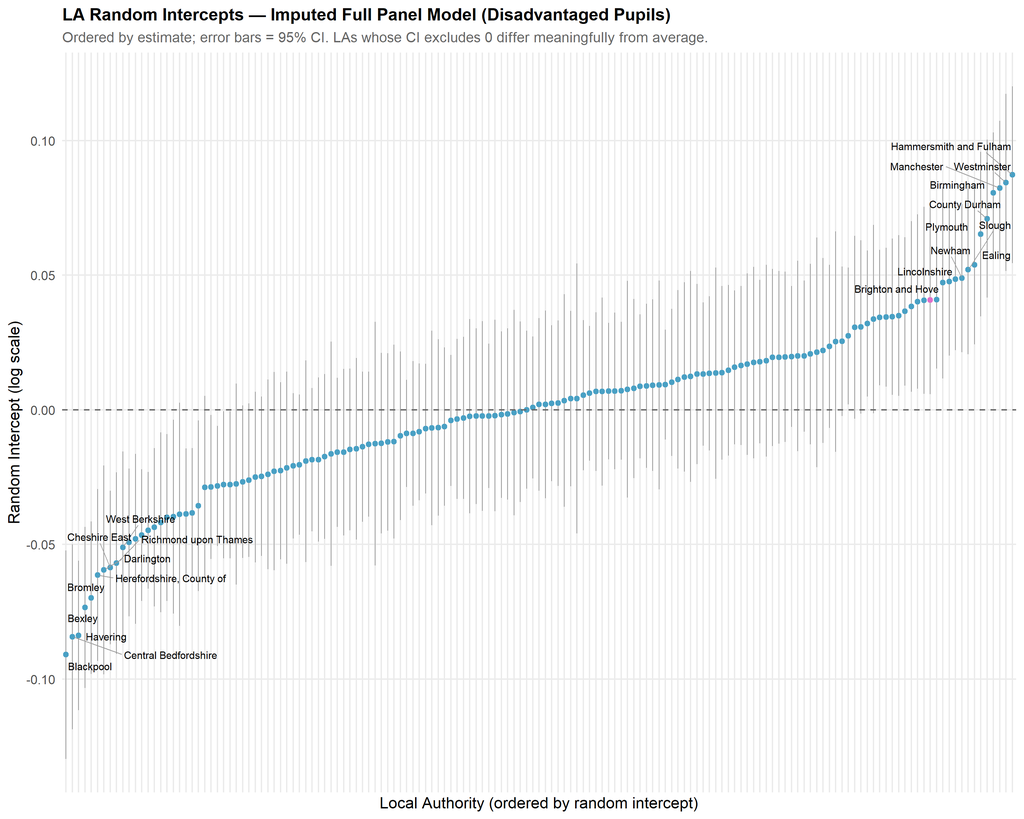

Figure 5: Caterpillar plot of LA random intercepts (imputed full panel model, Disadvantaged Pupils). Top and bottom 10 LAs labelled; Brighton and Hove in pink.

However, another question that follows that we can answer with the data to hand is, what might be stopping the LEA effect from being even more impressive? Why is the random intercept for Brighton not as positive and large as it is for, say, Plymouth (another comparable South Coast city) or larger cities like Manchester and Birmingham? What might be the most effective policy levers to pull to improve overall disadvantaged attainment even further in Brighton and Hove? And how do the most effective levers compare with those that were chosen?

## 6.2 The cost of absence

Fitting the model with and without a control for absence, on an identical sample, gives two very different pictures of the city. **Controlling for absence, Brighton and Hove ranks 15th of 151 local authorities for disadvantaged attainment. Without that control, it ranks 69th and is statistically indistinguishable from the national average.**

Neither number is the whole truth, and it would be easy to reach for whichever suits. Taken together, though, they say something more useful than either alone: the city’s schools appear to be genuinely effective for the pupils who actually turn up, and the city’s attendance problem is large enough to erase that advantage entirely in the aggregate.

The distance between the two rankings has a concrete interpretation. It is worth roughly **1.4 Attainment 8 points per disadvantaged pupil** — the difference between what the city’s disadvantaged children currently achieve and what they might achieve if their schools’ underlying effectiveness were not being drained away by absence. Read this way, attendance is not a caveat to a good-news story about Brighton and Hove. It is the story.

This also reframes what the 2024 consultation got right and what it got wrong. The council was not wrong that the city has a problem: unconditionally, its disadvantaged pupils do no better than the national average, and the raw attainment gap that motivated the consultation is real. What the consultation got wrong was the diagnosis. Presented with an attainment gap, it reached for the social composition of schools — one of the weakest levers in our modelling, and for disadvantaged pupils a lever that may point the wrong way — while the factor that actually separates the city’s conditional standing from its unconditional standing went undiscussed. The more accurate account is not that a high-performing city was mistaken for a failing one, but that a city with one specific, severe and addressable problem was prescribed a treatment for a different problem it did not have.

**Revised from Version 1.** Version 1 of this report put Brighton and Hove 7th of 151 for disadvantaged attainment. Under the improved prior-attainment control described in Section 5.4.2, the city ranks 15th (and 69th without an absence control). The city remains within the strongest tenth of authorities and the argument is unchanged — if anything the gap between the conditional and unconditional rankings is slightly wider — but the earlier figure partly reflected the weaker control.

## 6.3 Accelerating returns: comparing two candidate policy levers

The national modelling in the last section established that the relationships between attainment and most of its key school-level predictors are non-linear. Because the model operates on log-transformed variables, the same raw percentage-point change produces different effects depending on where a school starts. Selecting FSM and absence for illustration (as FSM levels were selected by the council as the main policy lever through its redistribution policies, while absence stands out from the national modelling) we can explore what this means. Reading from right to left in Figure 6 — that is, in the direction of policy improvement — the returns to reducing both absence and FSM *accelerate* as schools improve. Each successive percentage point of reduction buys a bigger predicted gain in Attainment 8 than the last.

But the two curves are not equal. Figure 6 places both variables on the same y-axis — the predicted Attainment 8 gain from a 1 percentage point reduction — allowing a direct comparison of the two policy levers at every starting level.

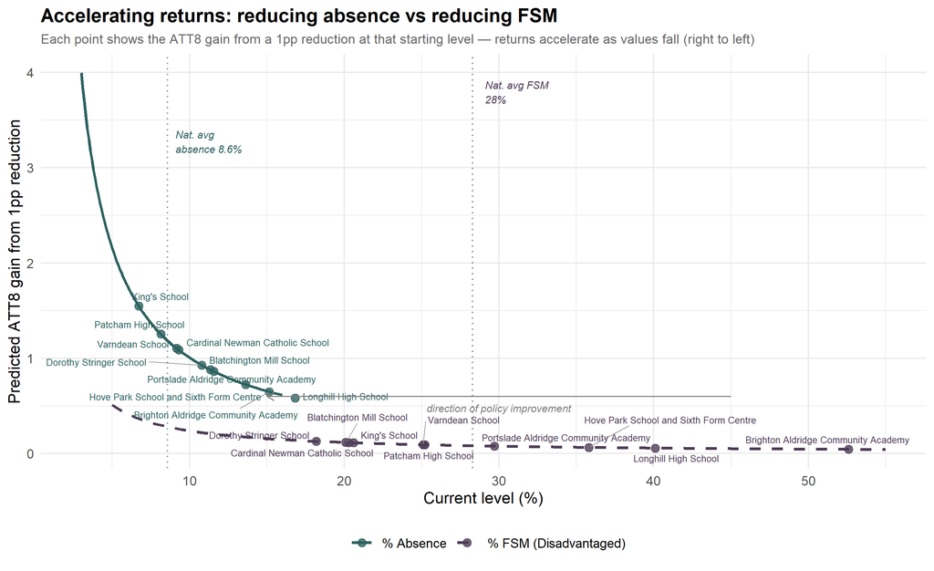

Figure 6: Accelerating returns: each percentage point of reduction buys a progressively larger ATT8 gain (reading right to left). Absence (green) delivers substantially larger gains than FSM (purple) at every level. Brighton & Hove schools are marked on each curve.

Three things are immediately visible. First, the absence curve sits well above the FSM curve at every starting level — a 1 percentage point reduction in absence always buys more predicted attainment than the same reduction in FSM (although, of-course, these two cannot be compared directly, but this is useful for illustrative purposes). Second, the gap between the two curves *widens* as values fall, meaning the comparative advantage of targeting absence grows as schools improve. Third, the Brighton & Hove schools (marked on each curve) cluster in the flatter right-hand portion for both variables, but the city’s position is far more extreme on absence than on FSM.

<sup>31</sup> derived by multiplying the model coefficient by the value of its log-transformed variable and then dividing one by the other

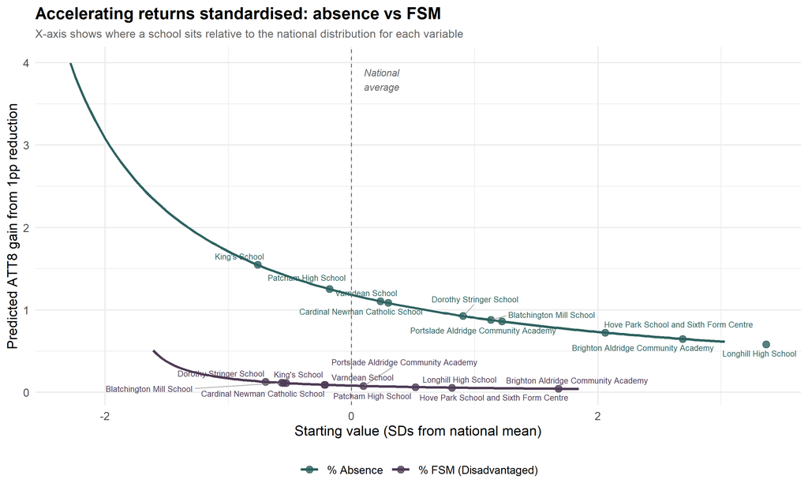

Figure 7: Accelerating returns standardised: x-axis shows SDs from the national mean. Brighton & Hove schools cluster near the national average for FSM but are extreme outliers on absence.

### 6.3.1 Absence in Brighton and Hove

Earlier analysis in this paper pointed to absence as being the most important factor affecting attainment, but how do the absence levels in Brighton and Hove compare to other LEAs in England?

Table 3: Highest-absence local authorities across all panel years (mean school absence %, rank).

| Local Authority | 2021-22 | 2022-23 | 2023-24 | 2024-25 |
| --- | --- | --- | --- | --- |
| Brighton and Hove | 10.8% (144/152) | 10.5% (137/152) | 11.0% (143/152) | 11.3% (152/152) |
| Knowsley | 12.6% (152/152) | 11.8% (149/152) | 11.9% (151/152) | 11.3% (151/152) |
| Southampton | 10.1% (119/152) | 10.6% (139/152) | 11.0% (145/152) | 11.0% (150/152) |
| Newcastle upon Tyne | 12.2% (151/152) | 12.9% (152/152) | 11.4% (150/152) | 11.0% (149/152) |
| Bradford | 11.5% (149/152) | 11.9% (150/152) | 11.2% (147/152) | 10.7% (148/152) |
| Middlesbrough | 11.8% (150/152) | 12.9% (151/152) | 12.2% (152/152) | 10.5% (147/152) |
| Plymouth | 11.1% (147/152) | 10.8% (144/152) | 11.3% (149/152) | 10.5% (146/152) |
| Sefton | 10.1% (122/152) | 10.3% (129/152) | 10.5% (133/152) | 10.4% (145/152) |
| Halton | 10.1% (118/152) | 10.3% (131/152) | 11.0% (144/152) | 10.3% (144/152) |
| North East Lincolnshire | 10.3% (135/152) | 10.7% (141/152) | 10.9% (141/152) | 10.3% (143/152) |
| Devon | 10.8% (145/152) | 10.9% (145/152) | 10.8% (139/152) | 10.3% (141/152) |
| Hartlepool | 10.2% (130/152) | 11.1% (148/152) | 10.5% (134/152) | 10.2% (139/152) |
| Bristol, City of | 10.6% (141/152) | 11.0% (146/152) | 11.0% (142/152) | 10.1% (136/152) |
| Blackpool | 9.8% (103/152) | 11.1% (147/152) | 11.3% (148/152) | 9.8% (131/152) |
| Gateshead | 11.4% (148/152) | 10.8% (143/152) | 11.2% (146/152) | 9.8% (130/152) |
| St. Helens | 10.7% (143/152) | 9.6% (103/152) | 10.0% (122/152) | 9.6% (124/152) |
| Torbay | 10.9% (146/152) | 10.2% (125/152) | 10.3% (126/152) | 8.5% (74/152) |

<sup>32</sup> Note — this table and the next use a simplified approximation of impact on Attainment 8. They take the model’s coefficient for the variable of interest, compute the proportional change implied by a given shift on the log scale, and then multiply that proportional change by the city-wide mean observed Attainment 8 (or the school’s own ATT8 where available) to convert it to Attainment 8 points. This is a shorthand for comparing schools side-by-side, but it produces slightly different point estimates from the full-model approach because it uses an average ATT8 as the base rather than each school’s specific predicted score.

Table 4: Potential Attainment gains to be made at different schools in Brighton and Hove by moving absence to the national average, 2024-25

| School | Current % Absence | National Average (Target) | Reduction needed (pp) | Predicted ATT8 change (%) | ≈ ATT8 points |
| --- | --- | --- | --- | --- | --- |
| Longhill High School | 16.8 | 8.6 | 8.2 | 14.99 | 4.9 |
| Brighton Aldridge Community Academy | 15.2 | 8.6 | 6.6 | 12.53 | 4.5 |
| Hove Park School and Sixth Form Centre | 13.6 | 8.6 | 5.0 | 10.06 | 4.1 |
| Portslade Aldridge Community Academy | 11.6 | 8.6 | 3.0 | 6.39 | 2.7 |
| Blatchington Mill School | 11.3 | 8.6 | 2.8 | 5.97 | 3.0 |
| Dorothy Stringer School | 10.8 | 8.6 | 2.2 | 4.88 | 2.6 |
| Cardinal Newman Catholic School | 9.3 | 8.6 | 0.7 | 1.70 | 0.9 |
| Varndean School | 9.2 | 8.6 | 0.6 | 1.36 | 0.7 |

8 out of 10 Brighton & Hove schools currently have absence above the national average. The potential gains for the schools with the highest absence rates are substantial — 3 to 5 GCSE points. Across these schools, achieving the national average would produce predicted gains averaging +2.9 Attainment 8 points per school. For disadvantaged pupils, the gains would be even larger — an average of +3.3 Attainment 8 points — because the absence coefficient is larger for disadvantaged pupils. Closing the absence gap to the national average would therefore simultaneously raise overall attainment and narrow the disadvantage gap.

Brighton & Hove’s absence rates are not a necessary consequence of its intake composition. The city has near-average levels of deprivation (FSM rates at the national median) but near-worst absence. Many local authorities with similar or higher FSM rates achieve substantially lower absence. This suggests that the absence problem is driven by as-yet unidentified local factors — attendance culture and parental attitudes towards attendance, enforcement practices, alternative provision use, or community-level dynamics — rather than being an unavoidable correlate of disadvantage. As such it is, in principle, solvable, if the drivers are properly identified.

The council has recently agreed to the creation of a cross-party working group on schools and we would suggest this might be one of the most pressing priorities for this group. It will certainly be the case that within the broad-brush absence statistics, big differences in outcomes might occur between, say, a few days missed for a family holiday by a student who otherwise has an impeccable attendance record, a SEND student who struggles with the school environment but who has strong family support and a student with caring responsibilities who lives a long way from their school and struggles to make the bus journeys required for regular attendance.

There may also be counter-intuitive interactions with absence and learning that are smoothed out at the school-level and that can only be unpicked at the classroom level and over time. For example, if otherwise disruptive students switch to being absent students at a higher rate in Brighton and Hove, this may have a positive impact on learning for those who remain in school with smaller class sizes and teachers able to devote more time to good pedagogy and less to classroom management. The city really needs to disaggregate this attendance problem and its impacts, and devise strategies to deal with the different causes and different outcomes in different ways.

### 6.3.2 Concentrations of disadvantage in Brighton and Hove

Given the council’s policy focus in 2024 was on reducing concentrations of disadvantage rather than on absence, it is worth quantifying what the FSM lever can realistically deliver. The answer, as Figure 6 makes visually clear, is: far less.

Table 5: Potential Attainment gains to be made at different schools in Brighton and Hove by moving %FSM to the city average, 2024-25

| School | Current % FSM | Target % FSM | Change in log(FSM) | Predicted ATT8 change (%) | ≈ ATT8 points |
| --- | --- | --- | --- | --- | --- |
| Brighton Aldridge Community Academy | 52.6 | 28.8 | -0.603 | 3.06 | 1.4 |
| Longhill High School | 40.1 | 28.8 | -0.332 | 1.67 | 0.8 |
| Hove Park School and Sixth Form Centre | 35.8 | 28.8 | -0.219 | 1.10 | 0.5 |
| Portslade Aldridge Community Academy | 29.7 | 28.8 | -0.032 | 0.16 | 0.1 |

Table 5 shows that for schools like BACA and Longhill, even very dramatic reductions of 10-20% in the proportion of disadvantaged pupils would likely only bring relatively modest changes to overall attainment at the school-level. And this is before factoring in that the relationship for disadvantaged students, on average for schools across England, works in the other direction. Of course, it would never be as simple as reducing levels of absence having an immediate and direct effect at the level predicted on attainment - these modelled figures are indicative and don’t account for a change in the levels of one variable having an influence on the levels of another (reducing absence, pushing up teacher sickness days, for example). However they do allow us to make useful comparisons between actionable policy levers relative to what we know about real situations in real schools. We can say with more confidence that when comparing the impact of reducing absence or disadvantage in a school, the absence coefficient is roughly 2.6 times as important as disadvantage in predicting attainment. This contradicts the council’s assertion at the start of the 2024 consultation that results in the city are ‘driven by advantage’: we can say that this is not the case - if anything is depressing attainment in the city’s schools and ‘driving’ results, given its impact and where Brighton and Hove sits in the national league tables, it is absence.

## 6.4 Brighton and Hove — low prior attainment

The examples above have zoomed in on the most important variable (absence) and the one chosen by the council as their policy lever (concentrations of disadvantage). However, as the earlier modelling showed, there are other important factors to consider, the main one of these being low prior attainment. The national modelling shows that unless we control for the mediating effects of low prior attainment on KS4 attainment, the effects of deprivation appear more damaging than they are — and indeed for schools with higher levels of deprived students, all other things being equal, once low prior attainment is accounted for, they are likely to achieve better results for their deprived students than those with lower levels. In Brighton and Hove schools, as shown in Figure 8, the two are strongly correlated, but without accounting for this factor, the FSM coefficient absorbs both the direct deprivation effect and the indirect effect operating through prior attainment.

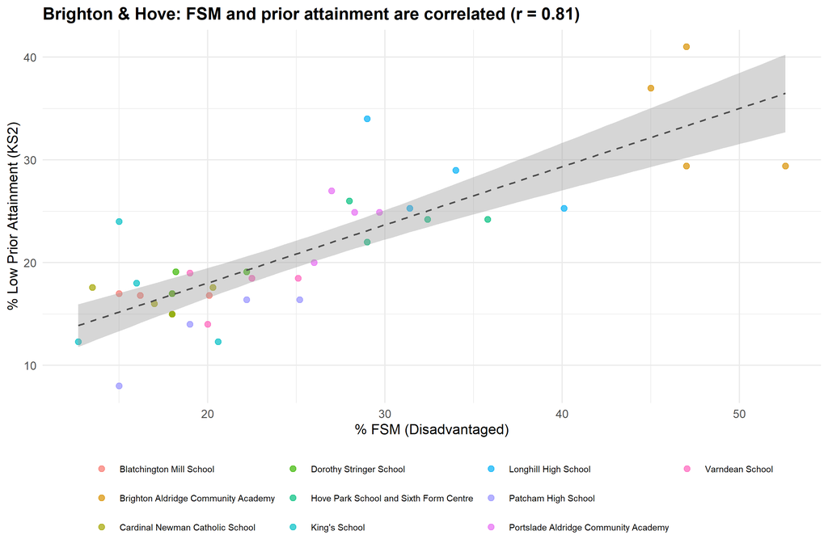

Figure 8: Correlation between low prior attainment and disadvantage across Brighton and Hove Schools, 2021-22 to 2024-25.

## 6.5 Alternative Local League Tables

One of the features of the debate in Brighton and Hove in 2024 related to perceived school ‘quality’ - and the desire for some to have choice to send their children to schools thought to be better quality. For many — councillors and citizens alike — impressions of secondary school ‘quality’ are predicated on Ofsted reports and raw GCSE results. Stories in the local press ranking schools in the city according to just their raw GCSE/Attainment 8 scores (Pring, 2025) certainly feed into a rather reductive view of quality based on attainment that fails to account for the varying intakes and cohorts across the schools in the city, both inflating impressions of ‘quality’ at some schools while unfairly depressing it at others.

Pring C (2025) [Top 10 best-performing schools in Brighton and Hove revealed](https://www.theargus.co.uk/news/25560982.brighton-hoves-10-best-schools-gcse-results/). *The Argus*.

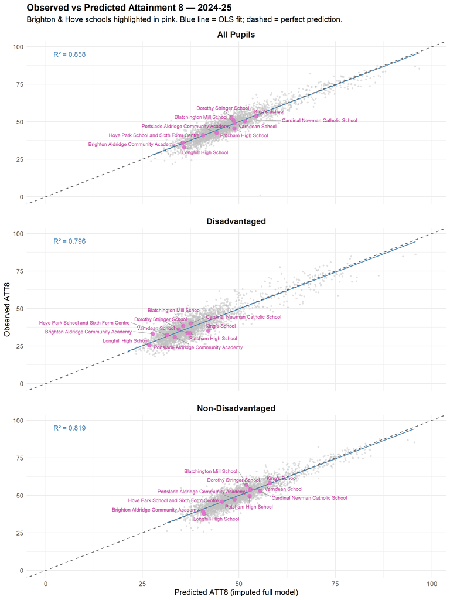

Figure 9: Observed vs predicted Attainment 8 for all schools (2024-25). Brighton & Hove schools highlighted in pink and labelled.

Figure 9 is a visual representation of this. The diagonal line represents where observed and predicted (by our model) attainment match perfectly. The further vertically above or below the line an individual school falls (in statistical terms, the greater its residual), the better or worse it performs relative to expectations. Brighton and Hove schools are highlighted and reveal an interesting picture. Most schools are close to the attainment levels we would expect, given their situations. Some perform much better than expected — e.g. Dorothy Stringer School — which achieves higher Attainment 8 results than expected for both disadvantaged and non-disadvantaged pupils, whereas Longhill High School performs worse than expected on both fronts.

The residuals in Figure 9 are captured in as set of what we might term value-added league tables below in Table 6 & Table 7. Perhaps the two most interesting schools in the city at other ends of this alternative spectrum are Brighton Aldridge Community Academy (BACA) and Patcham High School.

Table 6: All Pupils: value-added rankings (panel model residuals by year).

| Rank | School | 2021-22 | 2022-23 | 2023-24 | 2024-25 | Mean Residual |
| --- | --- | --- | --- | --- | --- | --- |
| 1 | Dorothy Stringer School | +2.2 | +2.8 | +2.0 | +5.2 | +3.0 |
| 2 | Varndean School | +2.4 | +2.4 | +5.1 | -0.0 | +2.5 |
| 3 | King's School | +3.3 | +0.7 | +4.8 | -0.9 | +1.9 |
| 4 | Brighton Aldridge Community Academy | +1.9 | +1.3 | +1.1 | +0.7 | +1.2 |
| 5 | Portslade Aldridge Community Academy | +3.7 | +0.4 | +2.2 | -1.8 | +1.1 |
| 6 | Hove Park School and Sixth Form Centre | +1.3 | +0.7 | +1.3 | +0.3 | +0.9 |
| 7 | Blatchington Mill School | -1.8 | -1.2 | +1.7 | +2.2 | +0.2 |
| 8 | Cardinal Newman Catholic School | +1.1 | -2.5 | +1.0 | -1.2 | -0.4 |
| 9 | Longhill High School | -0.4 | -2.4 | -1.2 | -2.9 | -1.7 |
| 10 | Patcham High School | -3.0 | -3.1 | -4.6 | -3.3 | -3.5 |

Table 7: Disadvantaged Pupils: value-added rankings (panel model residuals by year).

| Rank | School | 2021-22 | 2022-23 | 2023-24 | 2024-25 | Mean Residual |
| --- | --- | --- | --- | --- | --- | --- |
| 1 | Brighton Aldridge Community Academy | +3.0 | -1.4 | +4.5 | +5.6 | +2.9 |
| 2 | Cardinal Newman Catholic School | +2.6 | -5.7 | +6.2 | +2.6 | +1.4 |
| 3 | Dorothy Stringer School | +1.9 | +2.3 | -0.4 | +1.7 | +1.4 |
| 4 | Varndean School | +1.9 | +2.9 | +3.7 | -3.0 | +1.4 |
| 5 | Hove Park School and Sixth Form Centre | +2.7 | -2.7 | +1.8 | +1.0 | +0.7 |
| 6 | Blatchington Mill School | -5.3 | +0.8 | +4.5 | +2.7 | +0.7 |
| 7 | King's School | +4.5 | +1.1 | +3.5 | -6.8 | +0.6 |
| 8 | Portslade Aldridge Community Academy | +2.9 | -3.6 | +3.9 | -2.4 | +0.2 |
| 9 | Patcham High School | +3.8 | +1.2 | -11.9 | -3.9 | -2.7 |
| 10 | Longhill High School | -5.3 | -6.5 | +1.3 | -1.3 | -3.0 |

BACA and Patcham are particularly interesting examples to zoom in on. In the period of the 2024 consultation the public debate in the city shifted slightly, away from how the council’s proposals were going to improve disadvantaged attainment to how they were facilitating parental choice. Choice in this instance was largely to do with parents perceiving their local options to be poor and wanting access to alternatives. An activist group (Equity in Education[^33] — supported by another more established activist group — Class Divide[^34]) emerged from within the BACA catchment advocating for parents to have more options available to *not* send their children to that school. At the time BACAs Ofsted rating was ‘requires improvement’ and its raw attainment scores were some of the lowest in the city — creating an impression of that school being a poor option.

<sup>33</sup> https://educationequity.kit.com/

<sup>34</sup> https://www.classdivide.co.uk/

One of the outcomes that emerged from the vocal public debate, was a considerable number of parents from the BACA catchment opting to send their children to Patcham School (in the neighbouring catchment — see Figure 1) for entry in 2025 and 2026 — a school rated ‘Good’ by Ofsted and with raw attainment scores placing somewhere mid-table in the city. However, if we move beyond the raw attainment scores and blunt single-word Ofsted ratings, a very different picture of the two schools emerges. BACA is situated in one of the most economically deprived parts of Brighton and Hove, Patcham, one of the more economically prosperous. BACAs absence rates have been in excess of the very high city average. Patcham is one of two schools in the City with absence rates below the national average. The number of pupils entitled to Free School Meals attending BACA is around 50%, at Patcham it is around 25%. Around 30% of the pupils attending BACA have low prior attainment, at Patcham it is around 16%. When we account for these stark cohort differences in our model, a very different picture of school effectiveness occurs.

As the league tables above reveal, in 2024-25, a disadvantaged pupil attending BACA and taking their GSCEs would have, on average, left that school with GCSEs 5-points higher than if they’d attended a similar school with a similar profile elsewhere in England. Over the last 4 years, this would have averaged around 3 points higher. This is a boost way in excess of the fraction of a point differences that might be expected from altering the disadvantage mix in schools. BACA is doing incredibly well for its disadvantaged students and indeed out-performs every other school in the city by some margin — even those which in the popular imagination are viewed as the ‘best’ or most desirable schools in the city, e.g. Varndean, Cardinal Newman. BACA in some ways is the case study that illuminates the findings in the national data earlier in this paper which showed that disadvantaged attainment is higher in schools with bigger concentrations of disadvantaged students. In April 2025, BACA received a new Ofsted report which rated it ‘Good’ in all 5 areas of provision[^35] — a result unsurprising in the context of this data analysis, but probably more surprising to anyone just looking at raw prior attainment and previous Ofsted report.

<sup>35</sup> https://reports.ofsted.gov.uk/provider/23/136164

One thing other schools in the city certainly could learn from Patcham High School is in how to improve attendance rates. The school is one of only two in the city with attendance better than the national average. This is an actionable policy lever at the school-level. Without a deeper dive into attendance issues at the different schools in the city. Indeed, given we now know where the real problems in Brighton and Hove lie at the LEA level, one useful policy focus at the city level could well be exploring how schools like Patcham are able to keep attendance relatively high, while then allowing more school-level investigations into where under-performance might be occurring given our new knowledge of interacting structural drivers within the city.

## 6.6 The joint-signal view applied locally

The decomposition introduced at the end of section 5 lets us look at Brighton and Hove’s secondary schools through a finer lens. Each school can now be placed on a two-axis plane (Figure 10): vertically by its Expected Absence value-added in Attainment 8 points (positive = adding value above intake expectations, with attendance management already credited as part of that contribution), and horizontally by its residual absence in percentage points (positive = running more absence than intake predicts, negative = running less). The four quadrants correspond to the four school stories described earlier: schools adding value with attendance helping (top-left), schools adding value despite worse-than-predicted attendance (top-right), schools underperforming with attendance the cleanest single lever (bottom-right), and schools underperforming despite unusually good attendance management (bottom-left).

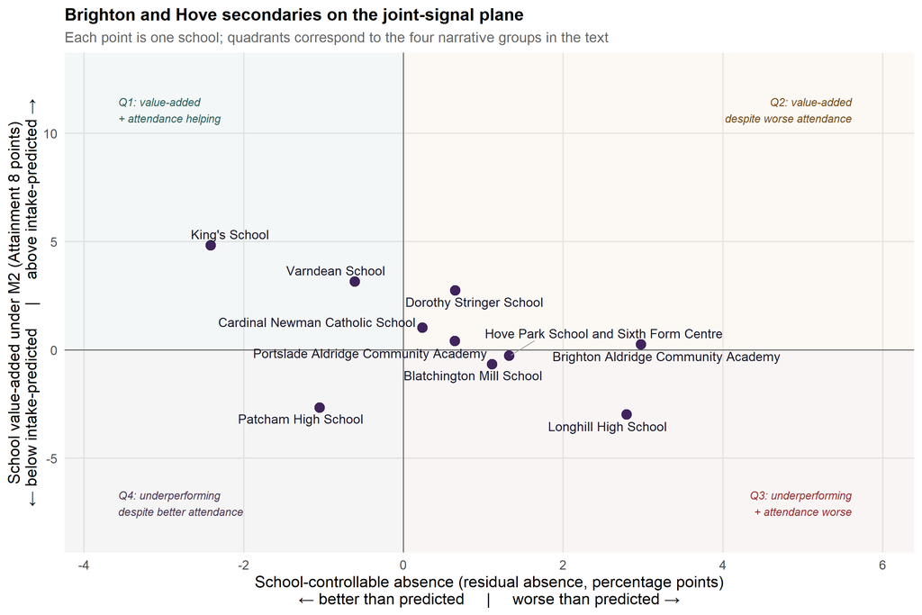

Figure 10: Brighton and Hove secondaries on the joint-signal plane: school value-added under M2 (vertical) versus the school-controllable absence component (horizontal). Each point is one school; reference lines at zero on each axis split the plane into the four narrative quadrants discussed in the text.

This local view reinforces the broader conclusion of this paper. The 2024 admissions consultation framed Brighton and Hove’s attainment story as one of disadvantage concentration, and the proposed remedy was redistribution. Both the headline modelling and this finer-grained joint-signal view tell a different story: the city’s attainment problem is overwhelmingly an absence problem, but **the school-controllable component of that absence is the smaller share — much of what individual schools are dealing with is structural, inherited from intake and area context**. Closing the city’s absence problem requires both school-level attention (clearest in the bottom-right quadrant) *and* cross-departmental work the council cannot delegate to schools alone. The attainment gains that would follow are real and substantial, and dwarf anything achievable by changes to admissions arrangements.

## 6.7 Brighton and Hove Reflections

### 6.7.1 The Danger of Single-Lever Policy Thinking

The Brighton and Hove experience illustrates what happens when policy makers latch onto a single causal narrative. The council’s 2024 proposals were built almost entirely on the premise that redistributing disadvantaged pupils would narrow the attainment gap. In the consultation papers released to the public[^36], it was stated:

<sup>36</sup> Brighton and Hove Council 2024 Consultation Papers can be downloaded from here: https://yourvoice.brighton-hove.gov.uk/en-GB/projects/school-admission-arrangements-public-consultation/1

> *“We also know that children from disadvantaged homes are less likely to do well at school and that can be made worse when more disadvantaged children all go to school together. We are looking at options for how we can help the city manage that issue better, including through our school admissions arrangements.”*

While this premise is false in the context of Macleod et al. (2015)’s analysis for the DfE, our more up-to-date modelling confirms these DfE findings of a decade ago and that this was, at best, a flawed understanding; at worst a belief driving policy with many losers and few clear winners.

Macleod S, Sharp C, Bernardinelli D, et al. (2015) *[Supporting the Attainment of Disadvantaged Pupils: Articulating Success and Good Practice](https://www.nfer.ac.uk/publications/supporting-the-attainment-of-disadvantaged-pupils-articulating-success-and-good-practice/)*. London: Department for Education.

As we have shown, concentrations of disadvantage are one of the weaker levers available for influencing school-level Attainment 8 — and for disadvantaged pupils specifically, the direction of the effect runs contrary to the assumptions underpinning the policy. Once absence and low prior attainment are accounted for, the residual direct effect of altering the social mix in schools is modest. As Figure 6 makes concrete: reducing absence to the national average at the city’s worst-affected schools could yield gains of 3–5 GCSE points, whereas even dramatic reductions in concentrations of disadvantage — halving the FSM proportion at BACA, for example — would yield gains closer to 1–2 points, but crucially, probably not for the disadvantaged pupils. The policy as designed was pulling a lever with relatively little mechanical advantage while ignoring one with considerably more.

This is not to say that concentrations of disadvantage are irrelevant — they are part of the story for all pupils and form part of the wider ecology of school characteristics. But the political appeal of a social mixing narrative — with its apparently intuitive logic and its socially progressive resonance — in Brighton and Hove, crowded out a more complex but more accurate understanding of the multiple, interacting drivers of attainment. The result was a set of proposals that risked disrupting a system that was, by national standards, performing remarkably well for its disadvantaged students without a clear evidential basis for expecting improvement.

We have also not touched upon the negative impacts of the policy that was chosen. One of the main drivers of the huge opposition to the proposals from within the city centred around the displacement outcome. In order to affect more mixing in schools, beyond the mixing already achieved by the 2023 Free School Meals priority, the 2024 consultation proposed to reserve 20% of places in central catchments for out-of-catchment children ahead of in-catchment children, while reducing the number of available places available in central catchment schools. The net effect of this was, by the council’s own calculations, that significant numbers of children living in central catchments would be unable to attend their catchment schools and be forced to attend another outside of their catchment. In achieving greater mixing via these policies, far more children would be having to travel much further to school - either by opting-in or being forced out. As Thomson (2023) showed in his analysis of NPD data, pupils who have to travel further to school are absent more often. Therefore the notion that more mixing can be achieved at “almost no cost” is false. If this extra travel resulted in even slightly more absence from schools - then any attainment gains would be undone immediately.

### 6.7.2 Absence as the Primary Policy Lever

It is worth pausing on this point in the context of the council’s own framing. The December 2024 cabinet report named *“reducing some schools’ barriers to success”* for disadvantaged pupils as one of its three core objectives for the 2026/27 admissions changes [^37]. Of the school-level barriers our modelling is able to quantify — intake composition, prior attainment, workforce stability, segregation, and absence — none has a larger or better-evidenced effect on disadvantaged attainment than absence. On the council’s own framing, in other words, the most direct route to *“reducing barriers to success”* for the city’s disadvantaged pupils points squarely at attendance.

<sup>37</sup> Brighton and Hove City Council (2024) *School Admission Arrangements 2026/27* — Cabinet Report, 5 December 2024 (decision to consult): https://democracy.brighton-hove.gov.uk/documents/s204040/School%20Admission%20Arrangements%202026-27.pdf. Brighton and Hove City Council (2025) *School Admission Arrangements 2026/27* — Full Council Report, 27 February 2025 (determination): https://democracy.brighton-hove.gov.uk/documents/s205834/School%20Admission%20Arrangements%202026-27.pdf.

Perhaps the most striking finding from this analysis, in the Brighton and Hove context, is the complete absence of absence from the policy narrative in the period preceding the 2024 consultation and then again with a more recent 2025 consultation. The city had the second worst absence rate in England in 2024-25 and has been consistently among the worst over the four years of our analysis. As the modelling demonstrates, absence is by far the most powerful predictor of school-level attainment, with its coefficient roughly 2.6 times larger than that of disadvantage. For disadvantaged pupils, the effect is even more pronounced — nearly half of the variation in school-level performance for this group is explained by whether pupils simply attend classes.

The irony is considerable. Brighton and Hove ranks 14th best out of 151 LEAs for disadvantaged attainment after controlling for structural factors — the LEA random effect tells us that something about the city’s schools are delivering results well above what the national picture would predict. Yet this strong underlying performance is being dragged down by an absence problem that sits at the extreme end of the national distribution. Were the city to bring its absence rates into line with the national average, the potential attainment gains — particularly at schools like Longhill and BACA — would dwarf anything achievable through changes to the social composition of schools.

That the council chose to focus its policy energy on redistribution rather than attendance is difficult to explain on evidential grounds. One possibility is that absence is a fundamentally harder problem to solve than admissions policies — more diffuse in its causes, more resistant to top-down policy intervention, and less amenable to the kind of structural reform that admissions changes represent. But difficulty of implementation should not be confused with importance of effect, and the failure to even acknowledge absence as the primary drag on attainment in the city represents a significant gap between the evidence and the policy response.

### 6.7.3 Absence is the mould, poverty is the damp

When an earlier version of this argument was presented locally, the campaign group Class Divide offered a memorable reply: *absence is the mould, poverty is the damp*. On this view, treating absence directly is futile, because the underlying poverty will simply keep bringing it back.

The analogy captures something real, and it deserves a serious answer rather than a dismissal. At pupil level the association between disadvantage and absence is strong and well evidenced (DfE, 2025b), and our own absence decomposition (Section 5.5) finds that a substantial part of school-level absence is inherited from intake rather than generated by the school. Any attendance strategy that ignores the material circumstances of families will disappoint, and we would not argue otherwise.

DfE (2025b) [Pupil absence in schools in England, Autumn and spring term 2024/25](https://explore-education-statistics.service.gov.uk/find-statistics/pupil-absence-in-schools-in-england/2024-25-autumn-and-spring-term).

But the analogy does not explain Brighton and Hove. Across English local authorities, differences in poverty account for remarkably little of the difference in absence: regressing each authority’s mean absence on its mean FSM eligibility, across all 152 authorities in the latest year of our data, yields an $R^2$ of just 0.05. Poverty explains almost none of why some areas have worse attendance than others.

Brighton and Hove’s own position makes the point plainly:

- Its FSM rate (28.8%) is slightly *below* the average across authorities (29.6%). On a poverty-only account its absence should be a little below average too — around 8.6%.
- It is 11.3%. That is an excess of 2.7 percentage points over what its disadvantage profile predicts — **the largest such excess of any authority in England**.
- Among the 20 authorities whose FSM rates are within two percentage points of Brighton and Hove’s, the city has the *highest* absence of all, some 2.4 percentage points above their average.
- And where absence fell in 94% of local authorities between 2021–22 and 2024–25, the city’s did not move.

There is damp in many places. The mould is markedly worse here, and unlike almost everywhere else it is not getting better.

The reasonable conclusion is not that poverty is irrelevant to absence — it plainly is not — but that poverty cannot be the explanation for Brighton and Hove’s position, and that treating the city’s attendance as an inevitable consequence of its social composition is not supported by the data. A substantial part of the city’s absence sits above what its intake predicts, and that is precisely the part local action can reach.

### 6.7.4 How much can schools matter at all?

It is worth setting all of this against what school-effectiveness research has consistently found, because the finding that redistribution is a weak lever is neither novel nor contrarian. Ever since Coleman et al. (1966), the share of variation in pupil outcomes attributable to differences *between* schools — as opposed to differences in the pupils they admit and the circumstances those pupils bring — has been estimated at something in the order of 8 to 15 per cent. The landmark English study by Smith and Tomlinson (1989) settled on around a tenth, and Teddlie and Reynolds (2000) confirm that broad range across countries and phases. Our own decomposition of the between-school component recovers the same order of magnitude.

Coleman JS, Campbell EQ, Hobson CJ, et al. (1966) *Equality of Educational Opportunity*. Washington, DC: U.S. Department of Health, Education,; Welfare, Office of Education.

Smith DJ and Tomlinson S (1989) *The School Effect: A Study of Multi-Racial Comprehensives*. London: Policy Studies Institute.

Teddlie C and Reynolds D (2000) *The International Handbook of School Effectiveness Research*. London: Falmer Press.

This matters for what any admissions policy can be expected to achieve. Moving pupils between schools operates on a comparatively small share of the variance to begin with, and it does so without altering the intake characteristics and social circumstances that account for most of the rest. A redistribution policy works on the smaller term while leaving the larger one untouched. That is not an argument for fatalism about schools — a tenth of the variance is still a great deal in a system of three and a half thousand secondary schools — but it is an argument for realism about what changing *which* school a child attends can deliver, relative to changing what happens once they are there.

### 6.7.5 The BACA Paradox

The case of Brighton Aldridge Community Academy and the choices made by parents in its catchment offers a particularly clear illustration of the damage that can be done when the public discourse around school quality operates on crude metrics. During and after the 2024 consultation, a vocal campaign emerged from the BACA catchment by the Equity in Education group. It’s difficult to ascertain whether this group emerged *because* of the choices already being made by parents who simply wanted more options, or whether the campaign was the influencing factor *behind* parents looking for education options beyond their local school — possibly both. But data released as part of objections to the Schools Adjudicator in the summer of 2025 revealed that a large number of families from within the BACA catchment opted for Patcham High School — a school rated ‘Good’ by Ofsted and sitting comfortably mid-table in raw league tables. But at this time, all that most would have known about BACA was it was a school with a ‘requires improvement’ Ofsted rating and raw attainment figures among the lowest in the city.

The alternative league table presented in this paper tells a very different story. BACA is the best-performing school in the city for disadvantaged pupils once we account for the structural factors that shape its intake. In 2024-25, a disadvantaged pupil at BACA left with GCSE results around 5 points higher than a comparable pupil at a similar school elsewhere in England. Over the four-year period of analysis, the average boost was around 3 points — substantially higher than any other school in the city, including those widely perceived as the ‘best’ options.

The implications are troubling. Parents, acting rationally on the basis of the information available to them — for example, raw league tables and single-word Ofsted judgements as well as word-of-mouth and the content and tone of public debates — were actively choosing the schools that might be a worse option if the value added by a school to their child’s likely GCSE outcomes were the most important factor. BACA’s April 2025 Ofsted upgrade to ‘Good’ in all areas vindicates what the data already showed, but came too late for the families who had already made their decisions on the basis of incomplete and misleading signals. This is not a criticism of those parents — they were operating in what we have described as a knowledge vacuum. It is, however, a powerful argument for the kind of contextualised benchmarking that this analysis makes possible.

### 6.7.6 The Cost of Speed Over Evidence

The institutional context in which these policy decisions were made deserves reflection. The shift to a Leader and Cabinet system concentrated decision-making power and enabled policy to be enacted through a whipped voting system. The consultation that followed in late 2024 was compressed in its timeline and limited in its scope for deliberative engagement. Without ease of data access, the time available to assemble, analyse and present counter-evidence was inadequate for the complexity of the issues at stake. Policy without genuine critical scrutiny runs the risk of push-back and unintended consequences.

This matters because the evidence base for secondary school attainment is complex. As the literature review and modelling in this paper demonstrate, the factors affecting outcomes are multiple, interacting, non-linear, and context-dependent. Understanding why a particular policy lever might or might not work in a specific local context requires more than citing a single strand of academic work — it requires the kind of synthesis and contextualisation that takes time, analytical capacity, and access to relevant data and tools. Institutional structures that compress deliberation timelines are particularly dangerous when the evidence requires careful handling and its implications counterintuitive. Had the analysis presented here been available at the outset — or had the consultation process allowed time for it to be developed — the quality of public scrutiny would have been substantially higher, even if the political outcome had ultimately remained the same.

### 6.7.7 What Is Driving the City’s Over-Achievement? And What We Don’t Yet Know

The LEA random effect for Brighton and Hove is large and statistically significant across all three attainment groups. After accounting for the structural factors in the model — disadvantage, absence, prior attainment, workforce characteristics, selectivity and segregation — schools in the city consistently outperform what the national picture would predict. For disadvantaged pupils, the city ranks 14th; for non-disadvantaged pupils, 4th; for all pupils, 5th in England.

This is a genuinely important finding that should re-frame the policy conversation. The starting point for the 2024 consultation was a narrative of failure — the city was presented as uniquely failing its disadvantaged students, sitting on a vast attainment gap, with radical structural reform required to address the problem. The evidence suggests the opposite: Brighton and Hove is one of the highest-performing LEAs in the country once we account for the factors that we know drive attainment. Rather than asking what the city is doing wrong, the more productive question is what it is doing right — and how that can be protected and extended?

The honest answer is that we do not yet know what produces this LEA effect. The random effect, by definition, captures variance that the fixed-effect predictors do not explain. It could reflect high levels of parental engagement and aspiration — Brighton and Hove has a well-educated population with a strong civic culture. It could relate to the quality of school leadership and governance across the city, or to effective local authority support services and school improvement programmes. It could be something about the collaborative relationships between schools, or community factors that are difficult to quantify. Identifying the sources of this over-performance is an important research question in its own right, and one that could require additional qualitative investigation or access to pupil-level data that goes beyond what is publicly available. What is clear, however, is that policy interventions which risk disrupting a well-functioning system without understanding what makes it function well carry substantial downside risk.

### 6.7.8 Conflicting Incentives: Viability Versus Attainment

It is worth acknowledging directly what was only partially articulated during the consultation: that a significant driver of the council’s proposals was financial rather than educational. The attempts to reduce Published Admission Numbers (rejected in the end after appeal to the Schools Adjudicator by parents and schools alike) at popular central schools and the creation of out-of-catchment priority places were designed, at least in part, to redirect pupil flows toward under-subscribed schools on the geographic periphery of the city. Keeping schools with declining numbers financially viable is a legitimate concern for any local education authority managing a school estate.

However, there is an inherent tension between optimising for financial sustainability and optimising for educational outcomes. If the net effect of these pupil flows is to move children from schools that are adding more value (in the contextualised sense demonstrated in this paper) to schools that are adding less, the aggregate impact on city-wide attainment could be negative. And if a school is forced to close because of poor strategic planning — parents not wanting to send their children miles out of town when there are more desirable and closer schools — is not the fault of the parents, but a failure of policy makers to listen, acknowledge this reality, and come up with alternative designs. Furthermore, the longer journeys that both ‘opt-in’ out-of-catchment priority and ‘forced-out’ in-catchment pupils further down the priority list would face, carry their own risks. As Thomson (2023) has documented, journey length and complexity are associated with higher absence rates — and given that absence is already the city’s most acute problem and the strongest predictor of attainment, a policy that even marginally increases absence for some pupils could be counterproductive in attainment terms. The financial case for the proposals and the educational case needed to be weighed against each other transparently, and it is not clear that this trade-off was adequately acknowledged during the public consultation periods.

Thomson D (2023) [Are pupils who live further away from their school absent more often?](https://ffteducationdatalab.org.uk/2023/11/are-pupils-who-live-further-away-from-their-school-absent-more-often/) *FFT Education Datalab*.

### 6.7.9 Lessons for Other Local Education Authorities

Brighton and Hove’s experience carries implications well beyond the city. The new DfE (2026) white paper sets national ambitions to halve the disadvantage attainment gap, improve attendance, reform admissions and tackle place-based disadvantage — including in coastal towns likely to be targeted by the new “Mission Coastal” initiative. Brighton and Hove may well be one such target.

DfE (2026) *[Every child achieving and thriving](https://www.gov.uk/government/publications/every-child-achieving-and-thriving/every-child-achieving-and-thriving-html-version)*. London: Department for Education.

The lesson from this case study is that national ambitions, however laudable, will founder if they are pursued at the local level without adequate analytical infrastructure. Every LEA has a different profile of challenges — different positions along the non-linear curves that relate disadvantage, absence, prior attainment and other factors, to outcomes. What works in one context may be irrelevant or counterproductive in another — cities, towns or collections of smaller settlements within LEAs with different configurations of schools, social geographies and education profiles. The open data published by the Department for Education provides most of the raw materials needed to understand these local contexts, but as we have argued throughout this paper, there is a crucial gap between the availability of raw data and the availability of actionable, contextualised intelligence that is accessible to the people who need it — councillors, school leaders, governors, and parents responding to statutory consultations.

We hope that the analysis we have presented and the tool we are about to introduce go some way towards bridging that gap. But we also recognise that tools alone are insufficient. What is also required is a culture of evidence-informed policy making that resists the temptation to reach for simple narratives, that takes seriously the complexity and context-dependence of educational outcomes, and that creates institutional space for genuine deliberation before irreversible decisions are made. Brighton and Hove’s experience should serve as a cautionary tale — but also, given the underlying strength of its schools, as a reminder of what is possible when the focus shifts from what is going wrong to understanding and building on what is going right.

# 7 The School Attainment Policy Simulator

## 7.1 Development Workflow

The analysis we have presented here has necessarily zoomed in on our case study city to illustrate the issues. But we cannot hope to foster an enhanced collective intelligence across LEAs and within and between communities when insights are hidden within mountains of available but largely unprocessed, tabular data. Part of this work has been funded by the UKRI National AI Research Hub for Collective Intelligence — AI4CI[^38] — an initiative to explore how emerging Artificial Intelligence tools can be brought to bear to help advance our collective intelligence across a range of domains including city planning and urban intelligence.

<sup>38</sup> https://ai4ci.ac.uk/about-the-hub/

<sup>39</sup> https://www.anthropic.com/claude/opus

<sup>40</sup> https://adamdennett.github.io/BH_Schools_Consultation/about.html

<sup>41</sup> https://huanfachen.github.io/QM/

<sup>42</sup> https://shiny.posit.co/

To this end, we have leant on the capabilities of Anthropic’s Claude Opus 4.6[^39] to assist in firstly, scaling up the initial analysis developed by one of us since the initial 2024 consultation — much of it available [here](https://adamdennett.github.io/BH_Schools_Consultation/about.html)[^40] and via teaching materials developed by one of us as part of the CASA0007 Quantitative Methods MSc module, available [here](https://huanfachen.github.io/QM/)[^41], and then secondly building this into an interactive tool. The exploratory descriptive analyses and explanatory models were developed without the assistance of Claude, however the data processing, cleaning, panel creation and scaling up of the analysis, implementing these models across multiple years and many iterations, could not have been achieved within the timeframes we have been able to achieve without this assistance. The Policy Simulator Tool is built in R Shiny[^42] and takes these foundational analyses and makes them both interactive and dynamic. Most of this front-end development was facilitated by Claude Opus 4.6 under iterative instruction.

## 7.2 The Attainment Policy Simulator Tool

The tool can be accessed here — https://adam-dennett.shinyapps.io/School_Attainment_Policy_Simulator/ — the tool is built on all of the open DfE data we have already described in the earlier analysis in this paper and in the supplementary materials linked to — mainly the last 4-years of attainment and other school-level statistics. It contains exactly the same underlying multilevel linear mixed effects model as has been described. The front page — Figure 11 — introduces the tool and its functionality in more detail and is the gateway to analytical tabs, detailed in Table 8.

[figure not shown]

Figure 11: Front Page of the Policy Simulator Tool.

Table 8: Analysis Tabs Available in the Policy Simulator.

[output not shown]

The tool allows for the easy visualisation of descriptive raw and modelled statistics at both the local authority and school levels. Perhaps most usefully for school leaders and policy makers, the simulator tab allows users to select a school and using the coefficients and linear or log-linear associations with the predictors used in the model, adjust sliders to see how changes in these variables might impact the attainment of all pupils, disadvantaged and non-disadvantaged pupils, at the school level.

[figure not shown]

Figure 12: Screenshot of the Dynamic Elements of the Policy Simulator.

The simulator is not designed to give definitive school level predictions — this is not its intended purpose and the sliders when moved will not and cannot account for potential changes in the coefficient values or levels associated with other variables in a truly inter-connected way. However, what it can do is zoom in on the unique starting position of any school in the dataset and allow users to see what the most important variable influencing attainment might be at that school and, potentially, what the most impactful lever could be.

This tool is far from the finished article, but it shows how the volumes of openly published DfE data can be used to provide more intuitive insights into the issues and challenges faced by different schools and different local authorities — providing much needed local context in debates which, as our experience in Brighton and Hove has shown, are often not as well informed by up-to date, geographically specific and timely data as they could be.

# 8 Conclusions

This paper set out to demonstrate that the Department for Education’s open data publications are a substantially underutilised resource for understanding and improving secondary school attainment in England. We believe the analysis and the tool presented here make that case convincingly. School-level attainment is remarkably predictable from a small number of readily available variables, and that predictability — once harnessed — creates an opportunity for far better-informed local policy making than was evident in our case study city.

We should be clear about what this analysis can and cannot claim. These are school-level models built from aggregate published data, not pupil-level analyses. The associations we identify are not experimental estimates of causal effects — they are the best approximations available from observational data structured to account for confounding and mediation across a rich set of predictors and hierarchical grouping factors. The Policy Simulator tool translates these associations into indicative, not definitive, projections. We do not claim that reducing absence by a given number of percentage points will mechanically produce the predicted gain in Attainment 8 — the real world is more complex than any model can capture. What we do claim is that these models are accurate enough, and the patterns consistent enough across years and specifications, to substantially improve the quality of the conversation around what matters most for school attainment and where policy effort is best directed.

We are yet to see the outcome of some follow-up work that the council has commissioned to explore the effectiveness of their Free School Meal priority policy, however the evidence from the four years of analysis in this work is that, at the school level at least, we would not expect big improvements in attainment from changes to the social composition of schools.

The same decomposition surfaces a fairer way of reporting school-level performance. Reading a school’s value-added alongside its residual absence — what we have called the joint-signal view — separates “this school adds points to attainment” from “this school’s pupils attend more than their intake predicts” into two distinct signals that the conventional single-residual league table folds together. Schools delivering strong attainment outcomes through unusually good attendance management are visible as a coherent management story; schools delivering strong outcomes despite an attendance gap (BACA being the city’s clearest example) are visible as pedagogically impressive cases with attendance still on the table as the next lever; and schools whose mid-table raw attainment hides an attainment shortfall once intake is properly accounted for (Patcham being the city’s clearest example) are visible as the most awkward cases for an LA to act on, where attendance management is *not* the available answer. Reporting both signals side by side, with explicit uncertainty intervals, is a more honest framing than the single number that conventional benchmarking produces — and would help align local policy conversation with what the data can actually support.

The School Attainment Policy Simulator developed as part of this work represents an attempt to bridge the gap between available open data and the actionable, contextualised intelligence that the people making decisions actually need. We do not claim it is the finished article — it can and should be refined, extended and subjected to critical scrutiny. But we believe it demonstrates what is possible when open data is combined with appropriate analytical methods and made accessible through interactive tools. Its development was substantially accelerated by the use of large language model assistance — specifically Anthropic’s Claude — as part of work funded by the UKRI AI4CI hub, and stands as an example of how emerging AI capabilities can enhance collective intelligence around complex policy questions, especially where capacity is low. We should make clear that expert interaction and iteration was crucial throughout — this was not an experience of ‘letting an AI do it all’ but more akin to working with a highly skilled junior front-end developer who, while technically adept, needed careful guidance around architecture and scrutiny of outputs along the way.

Our recommendations are directed at three audiences. For the Department for Education, we would urge continued investment in the quality and timeliness of open data publications, and consideration of how the analytical infrastructure demonstrated here might be supported or replicated at scale — perhaps through funding for local authority analytical capacity or the development of nationally maintained benchmarking tools that go beyond raw league tables. For local education authorities, the lesson from Brighton and Hove is that evidence-informed policy requires more than good intentions and a single strand of academic literature — it demands a willingness to engage with complexity, to resist the allure of simple narratives, and to create institutional space for genuine deliberation before decisions are made. For schools, governing bodies and parents, we hope this work demonstrates that there is more to school quality than raw Attainment 8 scores and single-word Ofsted ratings — and that contextualised benchmarking of the kind presented here offers a fairer and more useful basis for understanding how well a school is serving its pupils.

Our case study of Brighton and Hove — motivated by experiences of the 2024 and 2025 public consultations, should serve as both a cautionary tale and a source of encouragement. The caution is that policy made in haste, anchored to a single causal narrative and implemented without adequate regard for the full range of evidence, risks doing more harm than good — particularly when it could disrupt a system that is, by most measures, working well. The encouragement is that the raw materials for better policy already exist in the open data the Department for Education publishes, and that with the right analytical tools and a commitment to evidence over ideology, it is possible to understand with considerable precision what drives attainment in any local context and where the most productive interventions lie. The challenge now is to ensure that this understanding reaches the people who need it, in a form they can use, before the decisions are made — not after.

# CRediT authorship contribution statement

**Adam Dennett:** Conceptualisation, Methodology, Software, Formal analysis, Data curation, Writing – original draft, Writing – review & editing, Visualisation, Project administration.

# Declaration of generative AI use

The authors used Anthropic’s Claude Code (Claude Opus 4.6) to assist with the development of R data-processing pipelines, the implementation of multilevel model fitting and visualisation code, the formatting of tables and bibliography entries, and the rendering and deployment of Quarto outputs. Any analytical decisions and interpretations during the iterative analytical process were reviewed, verified and approved by the authors, who take full responsibility for the work.

# References

[figure not shown]

[UCL Centre for Advanced Spatial Analysis](https://www.ucl.ac.uk/bartlett/casa) · School Attainment Tool